# **Data Analysis Report**

## Globale Emissies en AQI-waardes per Regio

[figure not shown]

#### Versie 7.0

# Inhoudsopgave

- Data Inladen
- Dataframes
- Introductie
- Data
  - Global Emissions
  - Global Air Pollution
- Hypothese
- Vragen
  - Hoofdvraag
  - Deelvraag
- Exploratory Data Analysis
  - Deelvraag 1
  - Deelvraag 2
  - Deelvraag 3
  - Deelvraag 4
- Explanatory Data Analysis
- Conclusie
- Toekomst

## Data Inladen

Voor dit document zijn een aantal functies nodig die de mogelijkheid aanreiken om data op bepaalde manieren te transformeren. Om deze functies toe te passen moeten deze geïmplementeerd worden in de set-up.

In deze set-up worden alle functies die in dit rapport worden gebruikt aangeduid.

De set-up is als volgt:

```python
import pandas as pd #dataframe data manipulatie
import matplotlib.pyplot as plt #Python Visualisatie
from IPython.display import display, HTML #Dataframe weergave gebaseerd op HTML customisatie
import seaborn as sns #data visualisatie
import numpy as np #array toepassingen

MergedDatasetsDF = pd.read_csv('MergedDatasetsDF.csv', delimiter=';')  #MainDataset
EmissionAbsoluteDF = pd.read_csv('emissionabsolute.csv', delimiter=',') #EmissieDataset
```

## Dataframes

Dataframes bevatten de data die de gebruiker gaat transformeren om zo effectief te gebruiken in het rapport. In de eerste insantie wil ik dus alvast de dataframes creëren die zich voordoen als de fundamentele basis van alle data transformatie die zich af gaat spelen in dit rapport.

Hieronder heb ik de data van mijn datasets kort en gefilterd weergegeven, zodat de lezer al een beeld kan krijgen van de data die wordt gebruikt. Daarnaast worden deze dataframes ook weergegeven zodat ik kan checken of de data goed is geïmporteerd.

```python
exec(open('DF_Print.py').read())
```

```
Air Pollution DataFrame:
            Country             City                AQI Value           AQI Category
            ------------------------------------------------------------------------------------------------
            Russian Federation  Praskoveya               51                  Moderate
            Brazil              Presidente Dutra         41                  Good
            Italy               Priolo Gargallo          66                  Moderate
            Poland              Przasnysz                34                  Good
            France              Punaauia                 22                  Good

Methane Emissions DataFrame:
            region              emissions           type                segment
            ------------------------------------------------------------------------------------------------
            Africa              257.6112060546875        Agriculture         Total
            Africa              0.0520000010728836       Energy              Bioenergy
            Africa              130.7989959716797        Energy              Gas pipelines and LNG facilities
            Africa              69.74189758300781        Energy              Gas pipelines and LNG facilities
            Africa              213.98699951171875       Energy              Onshore gas
```

## Introductie

Dit document is geschreven met de intentie om leeruitkomsten binnenin het kader van data analyse aan te tonen. Deze data analyse wordt uitgevoerd doormiddel van zelf-gekozen data waarmee een authentieke opdracht wordt volbracht dat zich kan classificeren als een real-world problem.

Om lezers te informeren wat nu uiteindelijk het specifieke onderwerp van deze analyse is, wordt er een hypothese opgestelt die duidelijk aangeeft welke data ik ga gebruiken om een bepaalde correlatie binnenin de datasets te onderzoeken. Dit onderzoek wordt stapsgewijs uitgevoerd doormiddel van het beantwoorden van opgezette deelvragen die uiteindelijk leiden naar het beantwoorden van de hypothese via een relevante hoofdvraag.

Tijdens deze data analyse worden dus hoofd- en deelvragen opgesteld die worden onderzocht doormiddel van de Exploratory Data Analysis methodologie, waarna het doel is om deze vragen op te lossen via het gebruik van de Explanatory Data Analysis methodologie waarin mijn data-vaardigheden worden weergegeven.

Deze data-vaardigheden worden weergegeven in de vorm van datatransformatie en verschillende visuele data-weergaves die allemaal relevant zijn in verband met de datatypes van de oorspronkelijke data, en het doel van de respectieve hoofd- en deelvragen.

Tijdens de uitvoering van de verschillende vragen leg ik uit welke handelingen nodig waren, waarom deze handelingen werden ingezet, en hoe deze handelingen uiteindelijk invloed hebben op het beantwoorden van de hoofdvraag.

Ter afsluiting van het onderzoek van deze data wordt er een conclusie geschreven waarin wordt samengevat hoe alle handelingen binnenin dit document bijdragen aan het antwoord op de hoofdvraag, wat het antwoord van deze hoofdvraag uiteindelijk is, en wat dit resultaat betekend in de context van de data.

Uiteindelijk wordt er neergeschreven hoe deze analyse in de toekomst kan worden gebruikt om mogelijk verder onderzoek te doen naar vindingen die zijn gerealiseerd tijdens het evalueren van de bevonden resultaten.

Na het lezen van de conclusie en de toekomst sectie van deze analyse hoop ik de lezer voldoende geïnformeerd te hebben over mijn handelingen, redeneringen, en interpretaties met betrekking tot het "real-world" probleem.

## Data

De data die is gebruikt voor deze data analyse zijn [Global Emissions (2019-2022)](https://www.kaggle.com/datasets/ashishraut64/global-methane-emissions) en [Global Air Pollution (2022)](https://www.kaggle.com/datasets/hasibalmuzdadid/global-air-pollution-dataset), deze datasets zijn beiden via Kaggle verkregen en zijn aan elkaar te linken doormiddel van de eigenschap dat deze beiden negatieve gevolgen hebben op de gezondheid van de mensheid.

In dit hoofdstuk worden de verschillende datasets aangeduid, waarna deze specifiek worden uitgelegd zodat de redeneringen in de komende hoofdstukken volkomen te begrijpen zijn. Deze uitleg bespreekt bepaalde jargon en terminologie, en licht de context van de datasets toe.

De Global Emissions dataset is gebaseerd op data die is verkregen vanuit de [International Energy Agency](https://www.iea.org/) (IEA), de IEA is een intergouvernmentele organisatie die bestaat uit 29 landen. De IEA voert onder andere onderzoek uit naar energie statistieken die gepubliceerd worden op de respectieve website. Deze dataset is gecreëerd op basis van deze openbare data.

De Global Air Pollution dataset is gebaseerd op data die is verkregen vanuit [eLichens](https://www.elichens.com/), een organisatie wiens focus vooral ligt op de detectie van gas in de lucht dat een negatieve invloed heeft op het klimaat. Het bedrijf creëerd voornamelijk fysieke sensoren, maar de site zelf bevat ook data van uitgevoerd onderzoek dat in deze dataset is samengevat.

### Global Emissions

Deze dataset benoemd de standaard nominale data kolommen zoals Regio en Gebied, maar heeft meer unieke kolommen in de vorm van emissie sector, sector segment, en de reden voor de emissie. Deze uniekere kolommen bevatten weinig variabelen en zijn dus heel goed te gebruiken wanneer je vergelijkingen wilt maken op basis van eerder gemaakte vergelijkingen.

Daarnaast is er ook het bestaan van de Continue Numerieke Data Kolom in de vorm van de Emissions kolom. Deze kolom bevat de hoeveelheid methaan emissie in kiloton. Deze kolom bevat ontzettend hoge getallen waarbij dus op moet worden gelet wanneer deze worden gebruikt in visuele data-weergaven.

Tenslotte is er een data kolom die verschillend in kan worden gedeeld gebaseerd op wat er neer is geschreven. De kolom baseYear bevat een specifiek jaartal, of een specifieke jaarperiode die daardoor niet persé vergeleken kunnen worden. Er moet namelijk bekeken worden in hoeverre een vergelijking tussen een jaarperiode en een specifiek jaar een eerlijke vergelijking weergeeft. Er is geen manier om de jaarperiode op te splitsen in één specifiek jaar, wat er dus toe leidt dat deze kolom alleen wordt gebruikt indien we alleen resultaten met het specifieke jaartal, of met de specifieke jaarperiode gaan vergelijken, maar dat heeft vrijwel geen toevoeging aan de opgestelde hypothese, wat dus betekend dat baseYear geen gebruiksfunctie gaat hebben in dit rapport.

Heronder wordt alle data die in deze dataset zit neergeschreven met de respectieve datasoort en datatype, en, indien deze betrekking hebben op het onderzoek, de unieke variabelen van elke kolom:

#### Discrete Numerieke Data Kolommen:

- **baseYear**: Één specifiek jaartal waarin de meting is uitgevoerd

#### Continue Numerieke Data Kolommen:

- **Emissions**: De hoeveelheid Methaan emissie in kiloton

#### Nominale Data Kolommen:

- **Region**: Het gebied waarin de meting is uitgevoerd
- **Country**: Het land waarin de meting is uitgevoerd
- **Type**: Het type sector waaruit de emissie zich voordoet
  - Agriculture: Emissie vanuit de landbouw
  - Energy: Emissie vanuit energie opwekking
  - Other: Emissie vanuit andere bronnen
  - Waste: Emissie vanuit verspilling
- **Segment**: Deelsector van de primaire sector waaruit de emissie zich voordoet
- **Reason**: De reden voor de emissie
  - All: Emissie die vrij is gekomen door alle onderstaande redenen
  - [Flared](https://www.iea.org/energy-system/fossil-fuels/gas-flaring): Emissie die vrij is gekomen door affakkeling, oftewel het verbranden van gas
  - [Fugitive](https://www.thermofisher.com/blog/identifying-threats/what-are-fugitive-emissions-why-do-they-matter/): Emissie die onbedoeld vrij is gekomen tijdens industriële processen
  - [Vented](https://en.wikipedia.org/wiki/Gas_venting): Emissie die intentioneel vrij is gekomen tijdens aardgas- en methaanontluchting
- **Notes**: De bron van de specifieke data

#### Ordinale Data Kolommen:

- **baseYear** - een specifieke jaarperiode waarin de meeting is uitgevoerd

### Global Air Pollution

Deze dataset benoemd standaard nominale categorische data zoals landen en steden die later onder kunnen worden verdeeld in regio's om zo deze regio's te vergelijken. Deze data is op zichzelf niet ontzettend gebruikelijk door de vele variabelen aanwezig, en zijn daardoor dus beter te gebruiken wanneer deze getransformeerd wordt naar een overzichtelijkere kolom.

Om deze dataset verder te begrijpen is het van belang dat de lezer bekend is met het begrip AQI;

AQI staat voor "Air Quality Index" en is volgens [AirNow](https://www.airnow.gov/), een overheidssite die luchtkwaliteit meet, een statistiek die per stof in de lucht aangeeft of deze gezond of ongezond is. AirNow heeft ook [een tabel gecreëerd](https://www.airnow.gov/aqi/aqi-basics/) waaruit overzichtelijk valt af te lezen of een bepaalde waarde goed of slecht is. Deze tabel is hieronder nagebouwd.

Met deze kennis is de volgende data beter uit te leggen:

Er is nog ordinale categorische data in de vorm van de verschillende AQI-categorieën, deze categorieën geven dus aan of de hoeveelheid stof in de lucht goed of slecht is op zes verschillende niveau's gebaseerd op de tabel.

Daarnaast is er discrete numerieke data in de vorm van AQI-waardes, deze data geeft de specifieke AQI-waarde aan en verdeelt deze in de desbetreffende categorie. Echter is deze data specifieker dan de categorieën, en kan deze worden gebruikt voor metingen binnenin de specifieke categorieën.

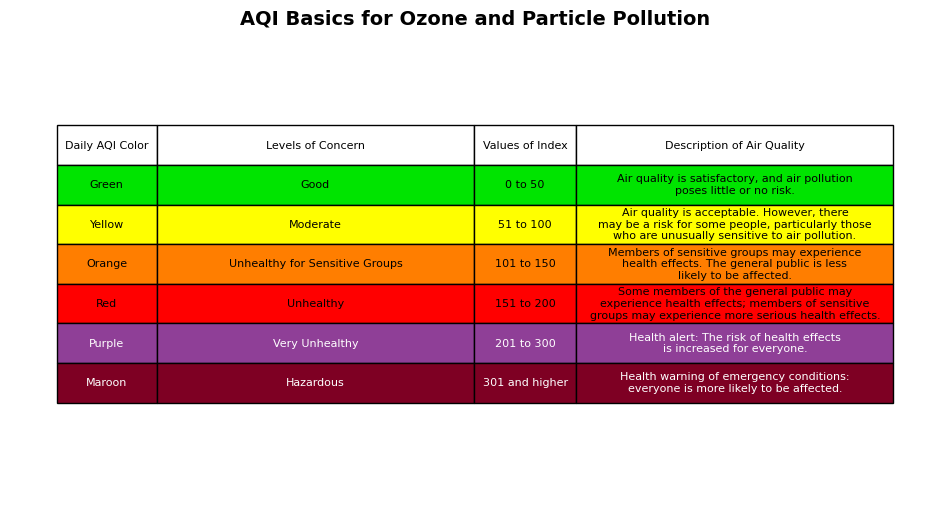

```python
exec(open('AQI_Table.py').read())
```

Hieronder wordt alle data die in deze dataset zit neergeschreven met de respectieve datasoort en datatype:

#### Discrete Numerieke Data Kolommen:

- **AQI Value**: De algemene AQI-Waarde in de lucht
- **CO AQI Value**: De AQI-Waarde voor Koolstofmonoxide in de lucht
- **Ozone AQI Value**: De AQI-Waarde voor Ozone in de lucht
- **NO2 AQI Value**: De AQI-Waarde voor Stikstofdioxide in de lucht
- **PM2.5 AQI Value**: De AQI-Waarde voor Stofdeeltjes kleiner dan 2.5 micrometer in de lucht

#### Nominale Data Kolommen:

- **Country**: Het land waar de meting is uitgevoerd
- **City**: De stad waar de meting is uitgevoerd

#### Ordinale Data Kolommen:

- **AQI Category**: De algemene AQI-Categorie aan de hand van de gemeten AQI-Waarde
- **CO AQI Category**: De AQI-Categorie aan de hand van de gemeten Koolstofmonoxide AQI-Waarde
- **Ozone AQI Category**: De AQI-Categorie aan de hand van de gemeten Ozone AQI-Waarde
- **NO2 AQI Category**: De AQI-Categorie aan de hand van de gemeten Stikstofdioxide AQI-Waarde
- **PM2.5 AQI Category**: De AQI-Categorie aan de hand van de gemeten AQI-Waarde voor Stofdeeltjes kleiner dan 2.5 micrometer

## Hypothese

Wanneer de data wordt bekeken zijn de enige numerieke data kolommen de verschillende AQI-waardes, en de totale emissiehoeveelheid die in een jaar of jaarperiode is gemeten. Dit betekend dat deze twee waardes grotendeels de hoofdrol gaan spelen binnenin alle verschillende vragen, in dat deze de enige twee waardes zijn die een meetbaar en vergelijkbaar resultaat opleveren.

De overeenkomende categorische data van beiden datasets zijn te vinden in de vorm van Regio en Land. Niet elk land komt overeen, sommigen landen en regio's zijn beschreven als overig, en één van de datasets benoemd niet de regio van het land. Deze problemen betekenen dat er geëvalueerd moet worden hoe deze problemen invloed gaan hebben op de verschillende resultaten, en of deze ervoor zorgen dat de resultaten vrijwel als ongeldig gezien kunnen worden.

Echter kan de data getransformeerd worden om de landen zonder regio in te delen in de bestaande regio's die bestaan binnenin de dataset, waardoor dat probleem al opgelost is.

Daarnaast is het vrij duidelijk dat industriële grootmachten sterker zijn benoemd binnenin de verschillende datasets dan kleinere landen die misschien al zijn gecategoriseerd in de "overige" regio's. De vraag zal dan nog steeds zijn hoeveel invloed deze data had gehad op het geheel, maar de hoofdvraag krijgt de mogelijkheid om een deelvraag te creëren waarin de data wordt vergeleken met- en zonder "overige" data.

De data betreft verschillende AQI-waardes die zijn te linken aan bepaalde regio's die tegelijkertijd ook bepaalde emissie-hoeveelheden uitstoten. Het is geen onverwachte assumptie om te denken dat een verhoogde emissie een grote invloed heeft op de luchtkwaliteit in de verschillende regio's, echter is de vraag in hoeverre deze emissie-uitstoten invloed hebben op een mogelijke verhoging in AQI-waarde, en ook wélke emissietypes deze verschillende AQI-types het meeste beïnvloeden.

Daarnaast is er natuurlijk ook de overweging dat grotere regio's vanzelfsprekende meer emissie-uitstoot hebben dan kleinere regio's, wat betekend dat het van belang is om deze in verhouding te gaan meten.

De hypothese die in dit rapport wordt onderzocht is;

*Specifieke emissietypes hebben een hogere invloed op de gemiddelde waardes van de verschillende AQI-types, waarvan deze invloed wordt geamplificeerd door een hogere emissie uitstoot gebaseerd op de grootte van een regio.*

## Vragen

Om de bovenstaande hypothese te bewijzen moet ik een aantal deelvragen opstellen en beantwoorden om de bijbehorende hoofdvraag op te lossen.

### Hoofdvraag

Om de kern van de beschreven hypothese the beantwoorden is de volgende hoofdvraag opgesteld:

*Hebben bepaalde emissies die zijn ontstaan door specifieke emissietypes een invloed op de gemiddelde waarde van de verschillende AQI-types in verhouding tot de grootte van de verschillende regio’s?*

### Deelvraag

Om deze Hoofdvraag te beantwoorden, zijn er een aantal deelvragen nodig die deze vraag ontleden, om zo geleidelijk naar het antwoord van de Hoofdvraag op te bouwen. Deze zijn;

1. Wat zijn de gemiddelde AQI-types in verhouding tot de grootte van de verschillende regio’s?
2. Wat is de gemiddelde emissie in verhouding tot de grootte van de verschillende regio’s?
3. Welke emissietypes hebben in het algemeen de grootste invloed op de verschillende AQI-types?
4. Welke emissietypes hebben in het algemeen de grootste invloed op de emissiehoeveelheid?

## Exploratory Data Analysis

De Exploratory Data Analysis is ervoor bedoeld om de deelvragen te beantwoorden en te onderzoeken. Wanneer deze deelvragen systematisch worden beantwoord, wordt de mogelijkheid aangeboden om de gehele dataset in detail te onderzoeken, zodat deze opgeschoond kan worden voor het beantwoorden van de hypothese.

Als begin is het belangrijk voor de schrijver en de lezer om te weten wat voor data er in de verschillende datasets zit, zodat er alvast een beeld wordt gecreëerd van hoe deze data mogelijk gebruikt kan worden.

Eerder in het verslag was er al beschreven wat alle variabelen betekenen, maar hieronder is nog een overzicht af te lezen.

```python
exec(open('MethaneTable.py').read())
```

Globale Emissie Data Tabel

| Kolom Naam | Data Type | Voorbeeld |
| --- | --- | --- |
| Region | String | Africa |
| Country | String | France |
| Emissions | Float | 5.2E+14 |
| Type | String | Energy |
| Segment | String | Bioenergy |
| Reason | String | Vented |
| baseYear | String | 2022 |
| Notes | String | Not Available |

```python
exec(open('PollutionTable.py').read())
```

Globale Luchtvervuiling Data Tabel

[output not shown]

Om de verschillende deelvragen te beantwoorden is het van belang dat de verschillende steden en landen worden ingedeeld in bepaalde Regio's. In de onderstaande tabellen is af te lezen dat de Dataframes gecombineerd zijn, in dat er te zien is dat elke rij nu een regio, land, en stad heeft.

Echter is de samenvoeging nog niet perfect in de zin dat sommigen landen niet voorkomen in de Regio dataset, om dit een beetje te verhelpen voor mijzelf, heb ik deze landen in een aparte tabel weergegeven, zodat er in een oogopslag te zien is welke landen nog ingedeeld moeten worden. Deze indeling wordt gedaan via een Python script, en zal doormiddel van ChatGPT de landen correct aan de desbetreffende regio koppelen.

```python
exec(open('MergeMissing.py').read())
```

```
Voorbeeld van gesorteerde AQI-waardes gebaseerd op regio:
```

| country | city | aqi value | aqi category | co aqi value | co aqi category | ozone aqi value | ozone aqi category | no2 aqi value | no2 aqi category | pm2.5 aqi value | pm2.5 aqi category | region |
| --- | --- | --- | --- | --- | --- | --- | --- | --- | --- | --- | --- | --- |
| Algeria | Adrar | 106 | Unhealthy for Sensitive Groups | 0 | Good | 45 | Good | 0 | Good | 106 | Unhealthy for Sensitive Groups | Africa |
| Algeria | Algiers | 154 | Unhealthy | 10 | Good | 33 | Good | 69 | Moderate | 154 | Unhealthy | Africa |
| Algeria | Tuggurt | 164 | Unhealthy | 1 | Good | 47 | Good | 0 | Good | 164 | Unhealthy | Africa |
| Algeria | Tazmalt | 117 | Unhealthy for Sensitive Groups | 1 | Good | 117 | Unhealthy for Sensitive Groups | 1 | Good | 56 | Moderate | Africa |
| Algeria | Constantine | 74 | Moderate | 3 | Good | 34 | Good | 16 | Good | 74 | Moderate | Africa |

```
Landen zonder gekoppelde regio:
```

| Russian Federation | United States of America | Belgium | Republic of North Macedonia | Finland | United Kingdom of Great Britain and Northern Ireland | United Republic of Tanzania | Haiti | Latvia | Viet Nam | Iran (Islamic Republic of) | El Salvador |
| --- | --- | --- | --- | --- | --- | --- | --- | --- | --- | --- | --- |
| Bulgaria | Guatemala | Ireland | Turkey | Democratic Republic of the Congo | Switzerland | Portugal | Côte d'Ivoire | Hungary | Spain | Myanmar | Papua New Guinea |
| Madagascar | Lithuania | Armenia | Serbia | Slovakia | Bosnia and Herzegovina | Czechia | Dominican Republic | Bolivia (Plurinational State of) | Chile | Panama | Kyrgyzstan |
| Mauritius | Greece | Malawi | Albania | NaN | Lesotho | Venezuela (Bolivarian Republic of) | Solomon Islands | Zimbabwe | Austria | Croatia | Honduras |
| Cambodia | Uganda | Republic of Moldova | Kingdom of Eswatini | Afghanistan | Zambia | Belarus | Malta | Rwanda | Sri Lanka | Burundi | Jamaica |
| Mali | Costa Rica | Nicaragua | Republic of Korea | Burkina Faso | Cabo Verde | Mauritania | Tajikistan | Barbados | Syrian Arab Republic | Lao People's Democratic Republic | Bhutan |
| Saint Lucia | Georgia | Nepal | Cyprus | Montenegro | Comoros | Iceland | Andorra | Luxembourg | Vanuatu | Aruba | Belize |
| Palau | Suriname | Singapore | Maldives | State of Palestine | Saint Kitts and Nevis | Monaco | NaN | NaN | NaN | NaN | NaN |

Een probleem dat zich voordoet is dat er niet genoeg waardes zijn voor elke stad en elk land, om te koppelen aan de andere dataset; er zijn bijvoorbeeld 15 verschillende AQI-metingen voor Algerije, maar voor dit land zijn maar 12 Emissie-metingen in de andere dataset.

Om dit probleem te omzeilen heb ik expres in mijn hypothese en vragen neergeschreven dat ik alleen naar de gemiddelde waardes van de verschillende regio's ga kijken, omdat ik anderes de data verkeerd interpreteer.

Zoals eerder beschreven zal ik de landen zonder gekoppelde regio ook nog linken aan de relevante regio doormiddel van ChatGPT:

```python
exec(open('MissingCountriesRegions.py').read())
```

|  | country | city | aqi value | aqi category | co aqi value | co aqi category | ozone aqi value | ozone aqi category | no2 aqi value | no2 aqi category | pm2.5 aqi value | pm2.5 aqi category | region |
| --- | --- | --- | --- | --- | --- | --- | --- | --- | --- | --- | --- | --- | --- |
| 840 | Afghanistan | Kuhestan | 151 | Unhealthy | 1 | Good | 41 | Good | 0 | Good | 151 | Unhealthy | Asia Pacific |
| 369 | Chile | Nueva Imperial | 61 | Moderate | 2 | Good | 2 | Good | 9 | Good | 61 | Moderate | Central and South America |
| 7 | Belgium | Puurs | 64 | Moderate | 1 | Good | 29 | Good | 7 | Good | 64 | Moderate | Europe |
| 178 | Portugal | Gondomar | 27 | Good | 0 | Good | 27 | Good | 2 | Good | 21 | Good | Europe |
| 681 | Honduras | La Entrada | 55 | Moderate | 2 | Good | 5 | Good | 4 | Good | 55 | Moderate | North America |

In de bovenstaande tabel zijn er vijf landen af te lezen die eerder niet aan een regio gelinkt konden worden door hun afwezigheid in de andere dataset, nu zijn deze wel gelinkt zodat deze waardes nu gebruikt kunnen worden in de vergelijking van regio's.

Ik zal dit dataframe via een ander Notebook ook opslaan als CSV, zodat ik deze altijd bij de hand heb voor toekomstige visualisaties. Deze importeer ik nu hieronder.

Een eerste visualisatie die uit gaat worden gevoerd is het in kaart brengen van de AQI-waardes van de verschillende AQI-types per Regio.

```python
AQI_Region_DF = pd.read_csv('sorted_air_pollution_with_regions.csv')

AQI_Region_DF.tail()
```

|  | country | city | aqi value | aqi category | co aqi value | co aqi category | ozone aqi value | ozone aqi category | no2 aqi value | no2 aqi category | pm2.5 aqi value | pm2.5 aqi category | region |
| --- | --- | --- | --- | --- | --- | --- | --- | --- | --- | --- | --- | --- | --- |
| 23458 | NaN | Kyaikkami | 54 | Moderate | 0 | Good | 20 | Good | 0 | Good | 54 | Moderate | NaN |
| 23459 | NaN | Bima | 25 | Good | 1 | Good | 25 | Good | 0 | Good | 24 | Good | NaN |
| 23460 | NaN | Marapanim | 25 | Good | 1 | Good | 15 | Good | 0 | Good | 25 | Good | NaN |
| 23461 | NaN | Calbuco | 36 | Good | 1 | Good | 15 | Good | 3 | Good | 36 | Good | NaN |
| 23462 | NaN | Sungairaya | 49 | Good | 1 | Good | 12 | Good | 0 | Good | 49 | Good | NaN |

In de bovenstaande dataframe is er ook te zien dat bepaalde steden niet aan een land zijn gekoppeld, en dus ook niet aan een regio, dit is te zien aan het woord **NaN** (Not a Number), en houdt in dat er geen data leesbaar is. Om deze reden zullen we hetzelfde moeten doen als eerder, maar dit keer met steden.

Ik ga niet de gehele tabel weergeven, want uiteindelijk waren er 415 steden **niet** gekoppeld aan een land. Ik zal weer ChatGPT deze steden laten koppelen aan alle landen, en ook weer aan de respectieve regio.

```python
exec(open('MissingCities.py').read())
```

|  | Granville | Kingston Upon Hull | New Waterford | Kingstown | Nanakuli | Lavagna | Ladispoli | Dong Hoi | Nettuno | Puebloviejo | Fiumicino | Nishinomiya |
| --- | --- | --- | --- | --- | --- | --- | --- | --- | --- | --- | --- | --- |
|  | Carteret | Ercolano | Bolama | Bairiki | Broome | Cananeia | Cavite | Prince Rupert | Roseau | Ardrossan | Stockholm | Tacloban |
|  | Tadotsu | Ternate | Torre Del Greco | Broadstairs | Ermoupolis | Parainen | Piombino | Pomorie | Port Dickson | Puerto Real | Rottingdean | Sakaiminato |

Zoals hieronder is weergegeven zijn er geen variabelen die geen waarde meer hebben, wat betekend dat we eindelijk elke stad en elk land hebben kunnen koppelen aan een specifieke regio, en dat we nu eindelijk kunnen beginnen met het creëren van visuele hulpmiddelen.

```python
CompleteRegion_DF = pd.read_csv('MergeAbsolute.csv')

CompleteRegion_DF.tail()
```

|  | country | city | aqi value | aqi category | co aqi value | co aqi category | ozone aqi value | ozone aqi category | no2 aqi value | no2 aqi category | pm2.5 aqi value | pm2.5 aqi category | region |
| --- | --- | --- | --- | --- | --- | --- | --- | --- | --- | --- | --- | --- | --- |
| 23458 | Myanmar | Kyaikkami | 54 | Moderate | 0 | Good | 20 | Good | 0 | Good | 54 | Moderate | Asia Pacific |
| 23459 | Indonesia | Bima | 25 | Good | 1 | Good | 25 | Good | 0 | Good | 24 | Good | Asia Pacific |
| 23460 | Brazil | Marapanim | 25 | Good | 1 | Good | 15 | Good | 0 | Good | 25 | Good | Central and South America |
| 23461 | Chile | Calbuco | 36 | Good | 1 | Good | 15 | Good | 3 | Good | 36 | Good | Central and South America |
| 23462 | Indonesia | Sungairaya | 49 | Good | 1 | Good | 12 | Good | 0 | Good | 49 | Good | Asia Pacific |

### Deelvraag 1

#### AQI-Categorisatie

*Wat zijn de gemiddelde AQI-types in verhouding tot de grootte van de verschillende regio’s?*

De eerste grafiek die word gecreëerd is de verdeling van de gemiddelde AQI-Categorieën per regio gebaseerd op de hoeveelheid steden die in de respectieve regio's zijn gemeten.

Deze AQI-Waarde omvangt de algemene AQI-Waarde in de lucht, en vat alle verschillende AQI-categorieën samen.

De totale hoeveelheid steden word weergegeven, maar de specifieke aantallen zijn niet nodig per categorie, deze zullen echter worden weergegeven in een gemaakte tabel hieronder. In principe is het idee dat er een beeld kan worden gecreëerd over de verhouding van de verschillende categorieën per regio.

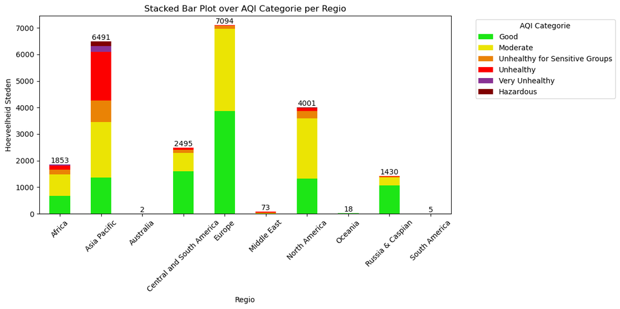

Aantal Steden per AQI Categorie en Regio

| aqi category region | Good | Hazardous | Moderate | Unhealthy | Unhealthy for Sensitive Groups | Very Unhealthy |
| --- | --- | --- | --- | --- | --- | --- |
| Africa | 673 | 6 | 800 | 160 | 185 | 29 |
| Asia Pacific | 1369 | 175 | 2079 | 1818 | 822 | 228 |
| Australia | 2 | 0 | 0 | 0 | 0 | 0 |
| Central and South America | 1602 | 1 | 695 | 73 | 114 | 10 |
| Europe | 3871 | 0 | 3082 | 12 | 129 | 0 |
| Middle East | 0 | 0 | 25 | 30 | 18 | 0 |
| North America | 1324 | 7 | 2261 | 116 | 274 | 19 |
| Oceania | 17 | 0 | 0 | 0 | 1 | 0 |
| Russia & Caspian | 1074 | 2 | 287 | 18 | 48 | 1 |
| South America | 4 | 0 | 1 | 0 | 0 | 0 |

```python
exec(open('StackedBar.py').read())
exec(open('AQI_Tabel_Count.py').read())
```

In de grafiek zijn er al een aantal opvallende waarnemingen te zien qua datainvoer;

- Er zijn een aantal regio's die vrijwel geen resultaten hebben.
- Er zijn regio's die elkaar overlappen.

Maar ook interessante waarnemingen qua de data zelf;

- De meest voorkomende AQI-categorie voor Europa, Rusland, en Centraal en Zuid Amerika is **Good**
- In Noord-Amerika, Africa, en Asia Pacific zijn er minder goede AQI-categorisaties dan minder goede AQI-categorisaties.
- In Asia Pacific is het nog erger in de zin dat er meer ongezonde AQI-categorisatie is, en dat deze veruit de meest ongezonde AQI-categorisatie heeft.
- Europa daarentegen heeft veruit de meeste goede AQI-categorisatie.

Echter is het belangrijk om te realiseren dat het mogelijk makkelijker of moeilijker is om deze categorisaties te beleven wanneer de regio veel groter is, en een grotere industriële grootmacht is.

Om die reden is het dus belangrijk voor de hypothese om ervoor te zorgen dat deze analyse wordt gedaan in verhouding tot de grootte van de verschillende regio's. De tabel hieronder vergelijkt het percentuele aantal AQI-categorisatie, om zo in kaart te brengen hoe deze verdeling en vergelijking in elkaar zit, daarnaast is er weer een tabel gecreëerd waarin in detail te zien is welke percentages bij welke categorie horen.

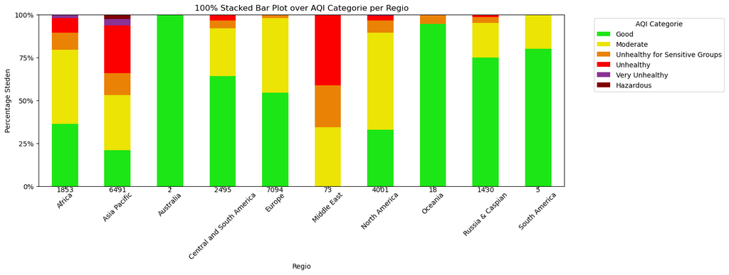

Percentage van Steden per AQI Categorie en Regio

| aqi category region | Good | Hazardous | Moderate | Unhealthy | Unhealthy for Sensitive Groups | Very Unhealthy |
| --- | --- | --- | --- | --- | --- | --- |
| Africa | 36.32% | 0.32% | 43.17% | 8.63% | 9.98% | 1.57% |
| Asia Pacific | 21.09% | 2.70% | 32.03% | 28.01% | 12.66% | 3.51% |
| Australia | 100.00% | 0.00% | 0.00% | 0.00% | 0.00% | 0.00% |
| Central and South America | 64.21% | 0.04% | 27.86% | 2.93% | 4.57% | 0.40% |
| Europe | 54.57% | 0.00% | 43.45% | 0.17% | 1.82% | 0.00% |
| Middle East | 0.00% | 0.00% | 34.25% | 41.10% | 24.66% | 0.00% |
| North America | 33.09% | 0.17% | 56.51% | 2.90% | 6.85% | 0.47% |
| Oceania | 94.44% | 0.00% | 0.00% | 0.00% | 5.56% | 0.00% |
| Russia & Caspian | 75.10% | 0.14% | 20.07% | 1.26% | 3.36% | 0.07% |
| South America | 80.00% | 0.00% | 20.00% | 0.00% | 0.00% | 0.00% |

```python
exec(open('StackedBar100.py').read())
exec(open('AQI_Tabel_Count_Percentage.py').read())
```

Wanneer we deze grafiek en tabel vergelijken met de eerder gemaakte beelden, begint de optiek al snel een beetje te veranderen. In alle eerlijkheid zijn de resultaten van Australië, Oceanië, en Zuid-Amerika te verwaarlozen op het moment, deze moeten opnieuw worden ingedeeld voor de komende grafieken, maar zijn zo insignificant dat er weinig zal veranderen.

In vergelijking met de eerdere beelden, zijn de volgende waarnemingen te zien:

- Ondanks het feit dat Europa de beste AQI-categorisatie heeft ontvangen, staat het in vergelijking tot de andere regio's niet aan de top zoals eerst verwacht.
- Rusland en Centraal en Zuid Amerika hebben een groter deel van goede AQI-categorisatie dan Europa.
- Wel heeft Europa een veel minder groot aandeel in een ongezondheids AQI-categorisatie in vergelijking met de andere regio's.
- Wanneer het goed in kaart wordt gebracht is het ontzettend duidelijk dat Afrika, Azië-Stille Oceaan, en het Midden-Oosten een ontzettend hoge ongezondheids AQI-categorisatie heeft in vergelijking met de Westerse wereld.

De nummers geven al een idee over wat er verder onderzocht kan worden;

- Welk type sector is er het meest waargenomen in Afrika, Azië-Stille Oceaan, en het Midden-Oosten waardoor de AQI-Categorisatie zo ongezond is?
- Verschillen deze sectoren en de reden voor emissie veel van de Westerse wereld?

Daarnaast is het belangrijk om te realiseren dat deze nummers over de algemene luchtkwaliteit gaat, er is baat bij om te onderzoeken hoeveel van elk AQI-type hier aan bijdraagd, en of deze dan ook overeenkomen met het resultaat van de bovenstaande vragen.

#### Data Opschonen

Zoals eerder is vernomen is er een klein aantal data dat niet goed is ingedeeld, deze moet worden opgeschoond zodat er in de komende visualisaties, en in de kern van het verslag geen foutieve en onnodige data wordt weergegeven.

Deze data is volledig opgeschoond via de volgende maatregelen:

- De regio's Oceania en Australia zijn nu correct toegevoegd aan de Asia Pacific regio.
- De regio South America is nu correct toegevoegd aan de Central and South America regio.
- Data die een Land, Stad, of Regio mistte heeft nu de respectieve data handmatig verkregen.

Initieel wilde ik de data uit het Midden-Oosten ook anders indelen, maar deze is volgens de originele data een opzettelijke regio ondanks de weinig gegevens voor deze regio.

Door deze redenering zijn er maar 25 van de 23462 verschillende gegevens foutief ingedeeld in vorige visualisaties, oftewel 0.11%. Deze visualisaties zijn hierdoor niet zo ontzettend aangetast dat deze opnieuw moeten worden weergegeven, en zullen daardoor niet opnieuw worden gemaakt.

Hieronder worden alle unieke regio's uit het nieuwe bestand laten zien, zodat er te verifiëren is dat de vermeldde plannen ook daadwerkelijk zijn uitgevoerd.

```python
exec(open('UniqueRegions.py').read())
```

```
Unieke Regio's:
- Africa
- Asia Pacific
- Central and South America
- Europe
- Middle East
- North America
- Russia & Caspian
```

#### CO AQI-Categorisatie

De grafieken die worden gemaakt na aanleiding van de eerste deelvraag zijn allemaal hetzelfde ingedeeld om de uniformiteit te behouden. De structuur van dit deel van het verslag zal dus veelal hetzelfde blijven, en zullen naast opmerkingen minder uitleg bevatten dan de eerste grafiek. Echter is de presentatie van data mogelijk anders naar aanleiding van de gevonden data.

De volgende grafiek laat de AQI Categorie voor Koolstofmonoxide zien, koolstofmonoxide is een giftig en mogelijk dodelijk gas, als deze te veel in de lucht zit zal de mensheid gewoonweg sterven. In elk land zijn hierom ook regels en wetten die ervoor moeten zorgen dat deze sterftegevallen worden voorkomen. Om deze reden is er een grote mogelijkheid dat er maar een tweetal landen zijn die geen goede koolstofmonoxide AQI-waarde bevat.

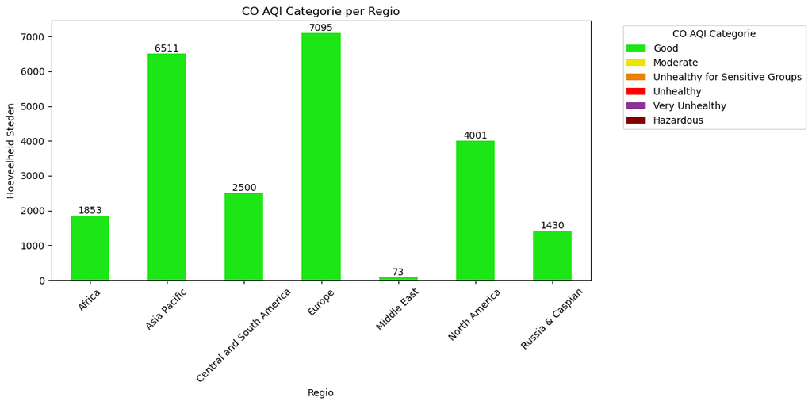

```python
exec(open('AQI_CO_bar.py').read())
```

Zoals is voorspeld, is voor het blote oog alleen maar "GOOD" te zien, maar wanneer we een tabel laten zien die alle "GOOD" data verbergd, is er het volgende te zien:

```python
exec(open('COBAD.py').read())
```

|  | region | country | city | co aqi value |
| --- | --- | --- | --- | --- |
| 381 | Africa | Democratic Republic of the Congo | Kasongo Lunda | 51 |
| 6724 | Asia Pacific | Malaysia | Miri | 67 |
| 19344 | North America | United States of America | Durango | 133 |

Uit bovenstaande data zijn drie steden af te lezen die geen goede CO AQI-Waarde hebben, echter is er de mogelijkheid dat deze foutieve data is, dus wil ik deze individueel bespreken;

**Kasongo Lunda:** is een stad in Congo die mogelijk een correcte AQI-waarde heeft laten meten. De AQI-waarde in Kasongo Lunda is nooit erg goed geweest, en is meestal moderate, ondanks het feit dat meetstations aangeven dat de normale AQI-waarde totaal niet zo hoog is als wordt aangegeven, geven deze wel aan dat alle andere AQI-waardes zo hoog kunnen zijn, wat mij laat geloven dat deze data correct is, maar dat de algemene AQI-waarde incorrect is.

**Miri:** is een stad in Maleisië die bekend staat als de **olie-stad** van Sarawak, en dat had voor mij een reden kunnen zijn om deze data als correct te vinden. Echter is het belangrijk om deze verder te onderzoeken; de verschillende AQI-waardes lijken redelijk op een lijn te zitten, met uitzondering van de NO2 AQI-waarde, echter is het mogelijk dat deze specifieke waarde verkeerd is ingevuld. Wanneer we de [luchtkwaliteit geschiedenis van Miri](https://aqicn.org/city/malaysia/sarawak/miri/) opzoeken, is er duidelijk te zien dat er geen moment in het verleden is geweest dat de AQI-waarde ooit deze nummers heeft bereikt, zelfs de slechtste dag heeft het niet bereikt. Hieruit valt te concluderen dat deze data foutief is.

**Durango:** is een stad in de Verenigde Staten dat bekend staat om haar rustieke atmosfeer, gigantische bergen, en mooie natuur. Wanneer de data voor deze stad wordt afgelezen is het al snel duidelijk dat er iets verkeerd is gegaan; maximale AQI-Waardes voor de gemiddelde AQI-waarde en voor de pm2.5 AQI-waarde, en een minimale waarde voor de onzone AQI-waarde geeft eigenlijk al aan dat deze waardes waarschijnlijk foutief zijn ingevuld. Ook is er een officiëel [document vanuit de gemeente van Durango](https://apcd.state.co.us/aqidev/tech_doc_repository.aspx?action=open&file=2022AnnualDataReport.pdf) die de luchtkwaliteit van Durango weergeeft, en duidelijk laat zien dat er in de geschiedenis van het land nooit een punt is geweest dat dit de CO AQI-waarde had kunnen zijn. Hieruit is te concluderen dat ook deze data foutief is.

Het feit dat twee van de drie uitzonderingsgevallen foutieve data bevatten maakt mij een beetje nerveus voor de komende bevindingen wanneer we de andere AQI types gaan onderzoeken, want wie weet hoeveel foutieve en zelfs "goede" gegevens wel correct zijn. Het project zal worden afgemaakt alsof de gegevens correct zijn indien dit gebeurd, maar de fout zal worden benoemd aan het einde van het verslag.

Echter is het wel interessant om te bekijken wat de verspreiding binnenin de GOOD-categorie is, om te zien in hoeverre de landen deze dodelijke stof respecteren, en om verdere vergelijkingen te maken met de andere stoffen verder in het verslag.

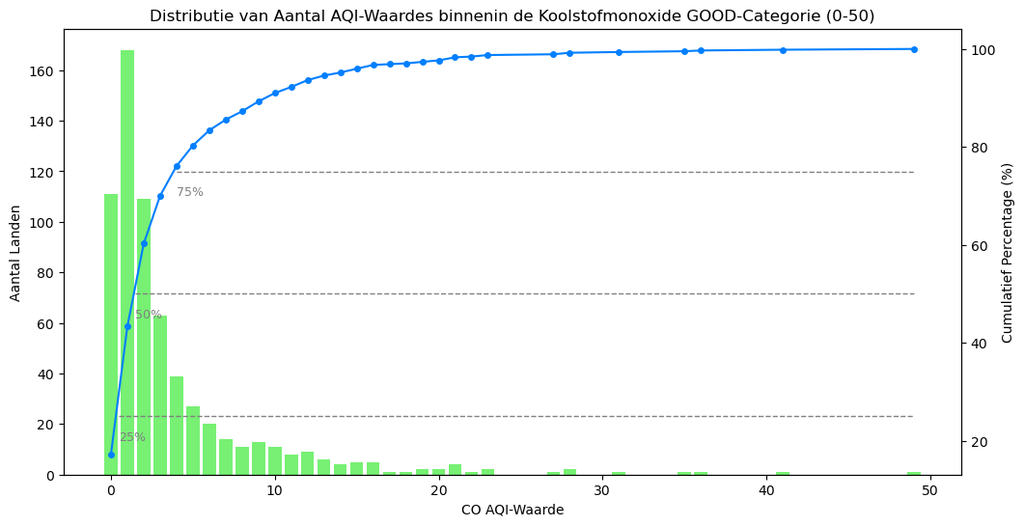

```python
exec(open('CO_GOOD_Verspreiding.py').read())
```

#### Ozone AQI-Categorisatie

De volgende grafiek geeft de Ozone AQI-categorie voor de verschillende regio's in dezelfde vorm als de vorige grafiek. [Ozone is een ingrediënt in de vorming van Smog](https://www.epa.gov/ground-level-ozone-pollution/ground-level-ozone-basics), en komt vrij door een chemische reactie wanneer vervuilende uitstoot in aanraking komen met zonlicht.

Deze vervuilende uitstoot komt vooral uit auto's, energiecentrales, raffinaderijen, en industriële verbrandingssystemen, en komt dus vaker voor dan Koolstofmonoxide. Terwijl er strenge regulaties zijn voor de uitstoot van Ozone, gaat er al snel te zien zijn dat deze stof heftiger in de lucht zit dan Koolstofmonoxide.

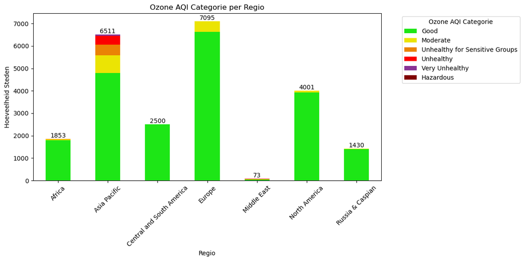

```python
exec(open('AQI_Ozone_bar.py').read())
```

Uit de bovenstaande grafiek is te zien dat grotendeels van de Ozone AQI-Categorisatie goed is, en dat er in elke regio wel een aantal matige categorisatie is. Het meest overduidelijke is dat er in Asia Pacific een groot aandeel ongezonde uitstoot is, en deze [consensus](https://edition.cnn.com/2024/03/18/climate/air-pollution-report-2023-asia-climate-intl-hnk/index.html) komt ook ontzettend vaak voor in het nieuws.

Allereerst was het idee dat alle ongezonde landen werden bekeken, maar er is af te lezen dat er ongeveer 500 steden een ongezonde categorisatie hebben. Om deze reden is het interessanter om te zien wat voor steden dan een "erg ongezonde" categorisatie hebben.

```python
exec(open('OZONEBAD.py').read())
```

Aantal Steden met een Erg Ongezonde Ozone AQI-Categorisatie

|  | Regio | Land | Aantal Steden | Percentage |
| --- | --- | --- | --- | --- |
| 0 | Asia Pacific | China | 36 | 67.92% |
| 1 | Asia Pacific | India | 2 | 3.77% |
| 2 | Asia Pacific | Indonesia | 7 | 13.21% |
| 3 | Asia Pacific | Iran (Islamic Republic of) | 4 | 7.55% |
| 4 | Asia Pacific | Malaysia | 1 | 1.89% |
| 5 | Asia Pacific | Pakistan | 3 | 5.66% |

Er zijn 53 steden met een erg ongezonde categorisatie, allemaal liggende in Azië-Stille Oceaan, en haast 68% van deze steden liggen binnenin China.

Dit is geen verassing, China staat bekend als de industriële grootmacht van de wereld, is het [op een na meest bevolkte land in de wereld](https://www.worldometers.info/world-population/population-by-country/), en heeft daardoor meer nodigheid aan [voertuigen en industriële processen](https://dspace.mit.edu/bitstream/handle/1721.1/61774/MITJPSPGC_Rpt196.pdf;jsessionid=837D627A33DDFC9B77B8D8C164FA3BBE?sequence%3D1).

Uit deze rapportages is te halen dat al deze data logisch is, in dat de grote uitliggers dus niet foutive data is. Ik kan echter verwachten dat er foutieve data is ingevuld voor bepaalde steden, maar het vinden van die steden is alsof je moet zoeken naar een speld in een hooiberg, vrijwel onmogelijk en niet de tijd waard.

#### NO2 AQI-Categorisatie

Stikstofdioxide is een schadelijk gas dat ontstaat wanneer er een chemische verbinding plaats vind waarin Stikstof de hoofdrol speelt. Deze stof komt vooral vrij door verkeer en industriële processen, en was in het verleden veel hoger door het veelgebruik van dieselauto's.

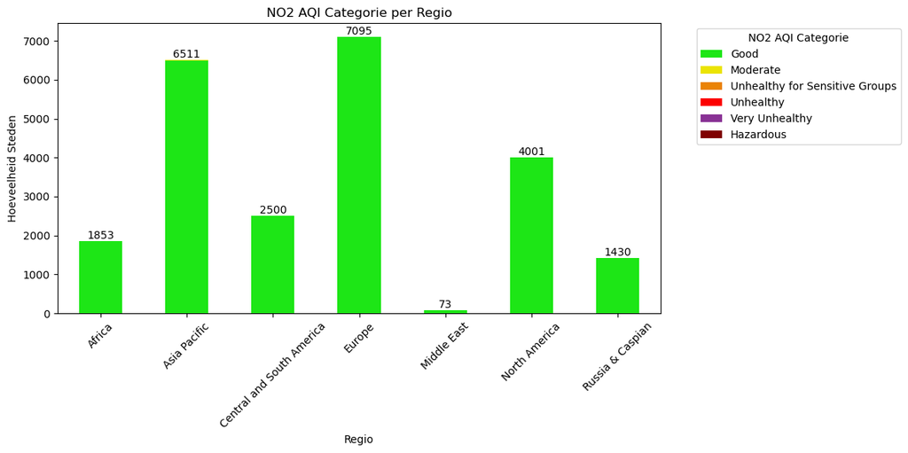

```python
exec(open('AQI_NO2_Bar.py').read())
```

Zoals eerst te zien was bij Stikstofdioxide, is er op het blote oog totaal geen categorisatie anders dan Goed af te lezen. Dit kan een resultaat zijn van onder andere de [Federal Clean Air Act](https://www.lung.org/clean-air/outdoors/what-makes-air-unhealthy/nitrogen-dioxide), en andere [wettelijke maatregelen](https://www.rivm.nl/ggd-richtlijn-medische-milieukunde-luchtkwaliteit-en-gezondheid/gezondheidseffecten-luchtverontreiniging/luchtkwaliteit-stikstofdioxide), maar het is onwaarschijnlijk dat er geen enkele stad is dat niet erger dan Goed heeft.

```python
exec(open('NO2BAD.py').read())
```

Aantal Steden met een NO2 AQI-Categorisatie

|  | Regio | Land | Aantal Steden |
| --- | --- | --- | --- |
| 0 | Africa | Algeria | 1 |
| 1 | Asia Pacific | China | 7 |
| 2 | Asia Pacific | Indonesia | 5 |
| 3 | Asia Pacific | Republic of Korea | 1 |
| 4 | North America | United States of America | 1 |

Zoals al eerder is gezien tijdens de analyse van de Ozone AQI-Waarde, zijn de AQI-Waardes in China en Indonesië erg slecht, deze zijn dus geen verbazingwekkende resultaten. Om deze reden zullen we deze niet bespreken in de analyse van de huidige AQI-Waardes.

In de volgende tabel worden de steden met de respectieve NO2 AQI-Waarde weergegeven:

```python
exec(open('NO2BADWORSE.py').read())
```

NO2 AQI Waarde per Land en Regio

|  | Regio | Land | Stad | NO2 AQI Waarde |
| --- | --- | --- | --- | --- |
| 0 | North America | United States of America | Durango | 53 |
| 1 | Africa | Algeria | Algiers | 69 |
| 2 | Asia Pacific | Republic of Korea | Seoul | 91 |

In de tabel zijn drie steden te zien met de betreffende AQI-Waardes, echter weten we al van **Durango** dat er een [document](https://apcd.state.co.us/aqidev/tech_doc_repository.aspx?action=open&file=2022AnnualDataReport.pdf) beschikbaar is waarin deze waardes zijn neergeschreven.

Ondanks het feit dat de meeste waardes fout waren voor Durango, lijkt het erop dat deze waarde zich redelijk goed aan de werkelijkheid aansluit, deze waarde is correct.

**Algiers** is de hoofdstad van Algerije en heeft historisch gezien redelijk slechte AQI-Waardes verkregen, en terwijl de NO2 AQI-Waarde dezer dagen redelijk goed zijn is het niet moeilijk te geloven dat een waarde van 69 een mogelijkheid was binnenin Algiers, in dat het de grootste stad van Algerije is, en daardoor meer uitstoot biedt.

**Seoul** is de hoofdstad van Zuid-Korea, is een van [de meest dichtstbewoonde steden in Zuid-Korea](https://worldpopulationreview.com/cities/south-korea), en ligt in Azië-Stille Oceaan, wat allemaal al redenen zijn om te geloven dat deze AQI-Waarde correct is. Echter is het moeilijk te geloven dat Seoul veruit de meest vervuilde stad is wanneer het aankomt op Stikstofdioxide in vergelijking met de industriële grootmacht in de vorm van China, in dat de hoogste NO2 AQI-Waarde in China 64 is. Wanneer we kijken naar [de meest vervuilde steden in de wereld](https://www.iqair.com/world-air-quality-ranking), staat Seoul tegenwoordig op nummer 63, het lijkt mij onmogelijk in overweging van de verkrijgbare data dat dit daadwerkelijk de correcte NO2 AQI-Waarde was.

Ook wil ik bekijken wat de verdeling is binnenin de goede AQI-categorie omdat dit resultaat de mogelijkheid biedt om dodelijke gassen te vergelijken. Voor Koolstofmonoxide was het te verwachten dat de meeste landen binnenin de goede categorisatie zouden liggen omdat deze een ontzettend giftig en dodelijk gas is, Stikstofdioxide is ook een dodelijk en gevaarlijk gas, maar is niet zo ernstig als Koolstofmonoxide. Het is interessant om te zien hoe de uitstoot van deze gevaarlijke stof is in vergelijking met de uitstoot van de erg dodelijke stof.

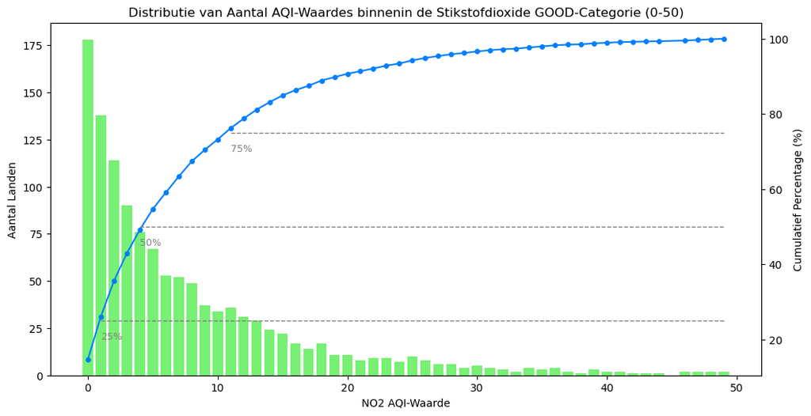

```python
exec(open('NO2_GOOD_Verspreiding.py').read())
```

Als we deze verdeling vergelijken met de verdeling van Koolstofmonoxide zien we al snel een groot verschil:

Het is vrij duidelijk dat CO veel serieuzer wordt genomen door de dodelijkheid van de uitstoot, echter is er wel op te merken dat er meer landen zijn met een AQI-Waarde van 0 of minder in de NO2 grafiek. Het lijkt erop dat alle landen voor de CO AQI-Waarde erg geconcentreerd zijn binnenin de laagste waardes, terwijl de landen voor de NO2 AQI-waarde meer verspreid zijn over alle andere waardes.

#### PM2.5 AQI-Categorisatie

PM2.5 omvangt [een fijnstof waarin deeltjes, of aerosolen, zweven](https://www.irceline.be/nl/documentatie/faq/wat-is-fijnstof). De PM2.5 aanduiding betreft Particulate Matter (Stofdeeltjes), en stofdeeltjes die kleiner zijn dan 2.5 micrometer, en is gevaarlijk door het feit dat [een kleiner stofdeeltje makkelijk en dieper in de longen kan komen](https://www.rivm.nl/ggd-richtlijn-medische-milieukunde-luchtkwaliteit-en-gezondheid/gezondheidseffecten-luchtverontreiniging/luchtkwaliteit-fijn-stof), en dus sneller kan zorgen voor aantastingen van de longen.

PM2.5 bestaat dus niet uit een specifiek gas, maar [eerder uit verschillende chemische species](https://ww2.arb.ca.gov/resources/inhalable-particulate-matter-and-health). Dit betekend ook dat het moeilijker is om deze efficiënt te reguleren, omdat deze verschillende deeltjes uit veel verschillende processen ontstaan die ook niet persé industrieel zijn.

In vergelijking met de andere stoffen gaat er waarschijnlijk dan ook een grotere variatie aan AQI-Categorisatie waar te nemen zijn, zelfs in regio's waar historisch gezien de AQI-Categorisatie voornamelijk positief is.

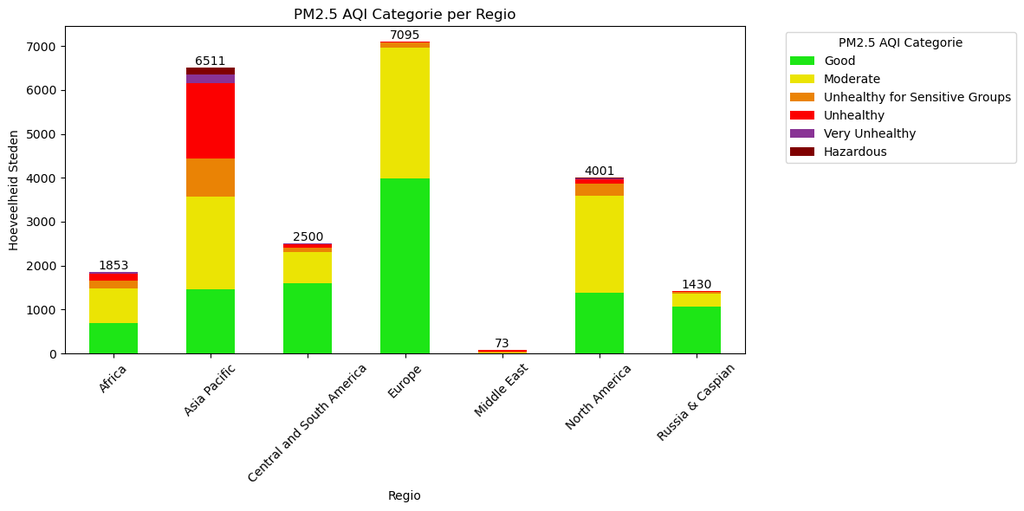

```python
exec(open('AQI_PM2.5_BAR.py').read())
```

Uit deze grafiek is af te lezen dat de PM2.5 fijnstof binnenin de verschillende steden enorm varieerd. In vergelijking met de andere uitstootgassen, ziet het er naar uit dat er in de meeste regio's vrijwel bijna net zo veel steden zijn met een Matige PM2.5 AQI-Waarde, als met een Goede PM2.5 AQI-Waarde.

De eerdere hypothese over de aanwezigheid van de bevonden AQI-Categorisatie was dus correct in dat alle regio's een wat mindere AQI-Categorisatie hebben dan normaal, echter is het voor deze verspreiding interessant om te zien wat de percentuele opbouw is van de AQI-Categorisatie binnenin de verschillende regio's om te observeren hoe deze in verhouding is tot de grootte van de regio's.

```python
exec(open('PM2.5_Distribution.py').read())
```

Percentage Distributie van PM2.5 AQI-Categorisatie per Regio

| region | Good (%) | Moderate (%) | Unhealthy for Sensitive Groups (%) | Unhealthy (%) | Very Unhealthy (%) | Hazardous (%) |
| --- | --- | --- | --- | --- | --- | --- |
| Africa | 36.97% | 42.80% | 9.71% | 8.63% | 1.57% | 0.32% |
| Asia Pacific | 22.55% | 32.38% | 13.22% | 26.45% | 2.99% | 2.41% |
| Central and South America | 64.24% | 27.84% | 4.56% | 2.92% | 0.40% | 0.04% |
| Europe | 56.31% | 41.71% | 1.82% | 0.17% | 0.00% | 0.00% |
| Middle East | 1.37% | 34.25% | 26.03% | 38.36% | 0.00% | 0.00% |
| North America | 34.42% | 55.21% | 6.82% | 2.90% | 0.47% | 0.17% |
| Russia & Caspian | 75.24% | 19.93% | 3.36% | 1.26% | 0.14% | 0.07% |

Uit de bovenstaande tabel is af te lezen dat Rusland en de Kaspische Zee de hoogste verhouding goede PM2.5 AQI-Categorisatie bevat, met Centraal en Zuid-Amerika, en Europa ook een redelijk goede verhouding in vergelijking met de andere regio's.

Omdat er zo veel variërende data is in vergelijking met de vorige grafieken, is het handig om deze data in een Heatmap te zetten. In deze Heatmap kan er dan een vergelijking worden gemaakt gebaseerd op Regio, of op AQI-Categorisatie in een overzicht door de toegevoegde kleurenschaal.

Hieruit is af te lezen dat de meeste landen een redelijke AQI-Categorisatie verdeling hebben wanneer Good en Moderate worden samengevoegd, in dat de verdeling van AQI-Categorisatie afloopt in Africa, Amerika, Europa, en Rusland.

Echter is ook af te lezen dat de trend van een slechte luchtkwaliteit binnenin Azië en het Midden-Oosten zich doorzet.

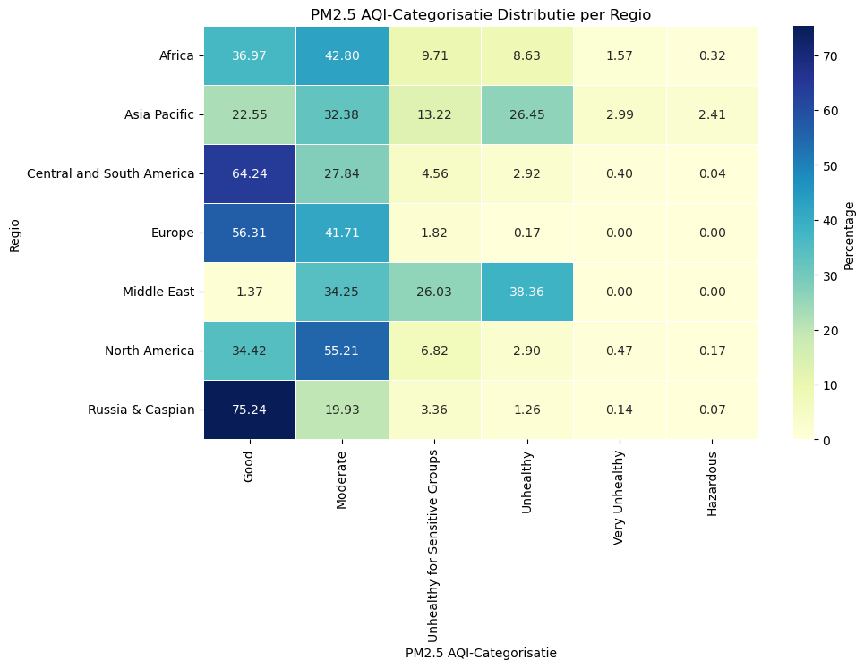

```python
exec(open('PM2.5_Heatmap.py').read())
```

Uit deze waarnemingen is het volgende te halen met betrekking tot de hypothese:

- Azië heeft een slechte AQI-Categorisatie wat mogelijk te koppelen valt aan de grootte van het land.
- Aan de andere kant heeft het Midden-Oosten ook een slechte AQI-Categorisatie terwijl die regio juist klein is.
- Rusland en Central and South America hebben een erg goede AQI-Categorisatie ondanks de grootte van de regio.
- Deze die bevindingen lijken aan te geven dat de grootte van een land minder invloed heeft op AQI-Categorisatie dan eerder verwacht.
- Alle regio's lijken zich goed te houden aan regelementen over de giftige en dodelijke stoffen.
- De enige AQI-Waarde variatie gebeurt in PM2.5 en Ozone voor bepaalde landen, dit zijn de enige AQI-Waardes die toedoen aan verder onderzoek.

### Deelvraag 2

#### Gemiddelde Emissie per Regio

*Wat is de gemiddelde emissie in verhouding tot de grootte van de verschillende regio’s?*

Het lijkt logisch om te denken dat een groot aantal uitstoot ook voor een slechtere AQI-Categorisatie zorgt, in dat er meer ongezonde stof in de lucht komt. Daarnaast is het ook logisch dat een grotere uitstoot verwant staat aan de grootte van de regio.

In de vorige deelvraag is er al beschreven dat het onwaarschijnlijk is dat de grootte van een land ook daadwerkelijk een negatieve invloed heeft op de AQI-Categorisatie van een regio, in dat Azië groot is met een slechte AQI-Categorisatie, maar het Midden-Oosten klein is met een slechte AQI-Categorisatie.

Om deze reden loond het om te kijken naar de gemiddelde uitstoot per vierkante kilometer, om te zien of deze enige invloed heeft op de AQI-Categorisatie.

Voordat er meteen wordt weergegeven wat het antwoord op de vraag is, is het interessant om te zien hoeveel emissie elke regio in totaal heeft uitgestoten.

Uit eerdere grafieken is het ontzettend duidelijk geworden dat Azië-Stille Oceaan overduidelijk de meeste uitstoot gaat hebben, zeker wanneer het cumulatief is weergegeven.

Om deze reden is het hoogstwaarschijnlijk dat deze veruit de meeste uitstoot heeft, waardoor andere regio's visueel niet waar te nemen zijn:

```python
exec(open('Emissie_Som.py').read())
```

|  | Regio | Totale Emissie (Ton) |
| --- | --- | --- |
| 1 | Asia Pacific | 1.183683e+09 |
| 6 | Russia & Caspian | 5.365468e+06 |
| 2 | Central and South America | 3.413036e+06 |
| 3 | Europe | 1.085460e+06 |
| 0 | Africa | 1.614085e+05 |
| 5 | North America | 7.837228e+04 |
| 4 | Middle East | 3.106882e+04 |

De tabel geeft de volgende inzichten:

- Zoals verwacht heeft Azië-Stille Oceaan veruit de meeste uitstoot.
- Verbazingwekkend genoeg heeft het Midden-Oosten de minste uitstoot ondanks de slechte AQI-Categorisatie die te zien is voor deze regio, dit zou kunnen betekenen dat het niet de uitstoot hoeveelheid is, maar juist de uitstootmanier die deze AQI-Waardes zo slecht beïnvloed.
- Rusland wordt vaak geclassificeerd als een [zwaar geïndustrialiseerde regio](https://www.oxfordreference.com/display/10.1093/oi/authority.20110803100002206), en heeft daardoor een groot aantal culumatieve uitstoot. Interessant om echter te zien, is dat de AQI-Categorisatie van Rusland juist ontzettend goed is, wat kan betekenen dat dit ook aan uitstootmanier ligt.

Omdat deze grote nummers zich niet goed lenen aan een normale schaal voor het weergeven van data, wordt er voor de volgende grafiek een [Logaritmische Schaal](https://nl.wikipedia.org/wiki/Logaritmische_schaal) gebruikt, waardoor de verhouding tussen regio's nog steeds gevisualiseerd kan worden ondanks het gigantische verschil tussen Azië en de andere regio's.

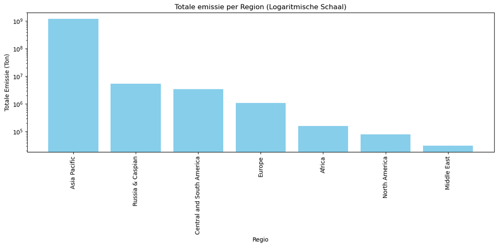

```python
exec(open('Logaritmische_Schaal.py').read())
```

In de vorige deelvraag was de gemiddelde AQI-Categorisatie berekent door een normale berekening van gemiddelde gebaseerd op hoeveelheid steden. Voor de vorige deelvraag mag dat gezien de AQI-Categorisatie gekoppeld is aan specifieke steden, en deze is niet te baseren op de grootte van de regio in vierkante kilometers.

Voor deze deelvraag is dat wel mogelijk, gezien het datatype zich daar toe leend.

De grootte van de verschillende regio's zijn als volgt:

```python
exec(open('KM2_Table.py').read())
```

|  | Regio | Grootte (kmÂ²) |
| --- | --- | --- |
| 0 | Asia Pacific | 41600000 |
| 5 | Africa | 30370000 |
| 3 | North America | 24700000 |
| 2 | Central and South America | 17800000 |
| 1 | Russia & Caspian | 17100000 |
| 4 | Europe | 10180000 |
| 6 | Middle East | 7500000 |

Omdat Azië-Stille Oceaan een te grote uitstoot heeft in vergelijking met de andere regio's, moet er weer een grafiek weergegeven worden die de logaritmische schaal gebruikt, zodat de andere regio's ook zichtbaar zijn.

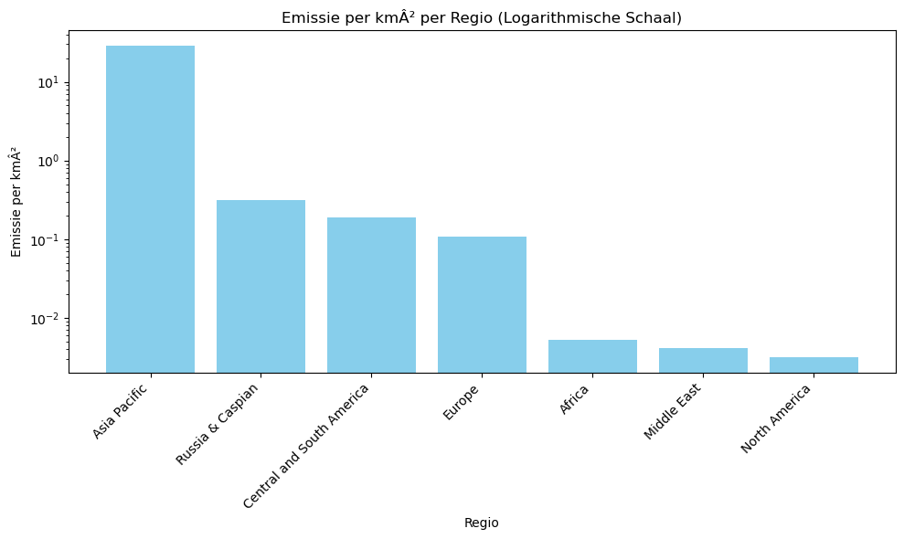

```python
exec(open('Logaritmisch_KM2.py').read())
```

Hieronder wordt nog een overzicht weergegeven van de verschillende waarnemingen, waarna een conclusie wordt getrokken op de deelvraag.

```python
exec(open('Overzicht_km2.py').read())
```

|  | Regio | Emissie | Grootte (km²) | Emissie per km² |
| --- | --- | --- | --- | --- |
| 1 | Asia Pacific | 1.183683e+09 | 41600000 | 28.453924 |
| 6 | Russia & Caspian | 5.365468e+06 | 17100000 | 0.313770 |
| 2 | Central and South America | 3.413036e+06 | 17800000 | 0.191744 |
| 3 | Europe | 1.085460e+06 | 10180000 | 0.106627 |
| 0 | Africa | 1.614085e+05 | 30370000 | 0.005315 |
| 4 | Middle East | 3.106882e+04 | 7500000 | 0.004143 |
| 5 | North America | 7.837228e+04 | 24700000 | 0.003173 |

Uit deze waarnemingen is het volgende te halen met betrekking op de hypothese:

- Landen met een grotere som uitstoot zijn zo geadvanceerd in hun identiteit als industriële grootmacht, dat de emissie per vierkante kilometer vrijwel geen invloed heeft op de respectieve positie in de rangschikking van de regio's.
- Het Midden-Oosten heeft heel weinig uitstoot per vierkante kilometer in vergelijking met andere regio's, maar heeft ondanks dat feit toch een vrij slechte AQI-Categorisatie.
- Rusland heeft heel veel uitstoot per vierkante kilometer in vergelijking met andere regio's, maar heeft juist een erg goede AQI-Categorisatie.
- Deze twee voorbeelden geven de mogelijkheid om verder onderzoek te doen naar de manier van emissieuitstoot, in dat deze veel meer invloed kan hebben op AQI-Categorisatie dan de hoeveelheid uitstoot.

### Deelvraag 3

#### Invloed van emissietypes op AQI-Waardes

*Welke emissietypes hebben in het algemeen de grootste invloed op de verschillende AQI-types?*

Om deze deelvraag te beantwoorden is het belangrijk om allereerst inzicht te krijgen in de desbetreffende emissietypes, en hoe vaak deze voorkomen in de dataset. Er is namelijk weining baat in het onderzoeken van emissietypes wanneer sommigen véél minder, of véél vaker, voorkomen dan de andere emissietypes, in dat deze dan van nature veel invloed zal hebben op de AQI-Waardes.

Zoals eerder neergeschreven zijn de emissietypes als volgt:

- Agriculture: Emissie vanuit de landbouw
- Energy: Emissie vanuit energie opwekking
- Other: Emissie vanuit andere bronnen
- Waste: Emissie vanuit verspilling

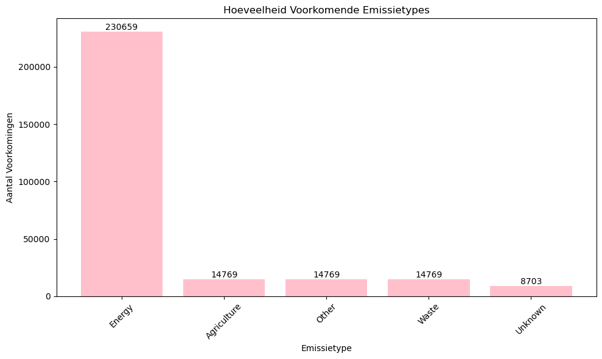

```python
exec(open('Emissietype_Count.py').read())
```

Uit bovenstaande grafiek is af te lezen dat er een discrepantie is tussen de hoeveelheid voorkomende emissietypes, in dat het Energy emissietype haast 16x groter is dan de andere individuële emissietypes.

Daarnaast is er af te lezen dat uitstoot vanuit landbouw, andere bronnen, en verspilling, allemaal dezelfde hoeveelheid voorkoming hebben, wat mij weer meteen laat geloven dat er iets mis is met deze data.

Via [Our World in Data](https://ourworldindata.org/emissions-by-sector) is uit de grafiek af te lezen dat er inderdaad veel meer uitstoot is ontstaan door energie opwekking. Deze grafiek laat alleen CO2 zien, maar is een goede indicatie van een trend voor alle andere stoffen.

Deze grafiek is hieronder ook weergegeven:

```python
from IPython.display import SVG, display
display(SVG(filename="ghg-emissions-by-sector.svg"))
```

[figure not shown]

Ondanks het feit dat energie opwekking voor meer uitstoot zorgt in vergelijking met de andere types, is dat nooit 16x zo veel dan de andere types.

Door bovenstaande redenen valt er te concluderen dat de huidige dataset **niet** een accuraat beeld geeft van de werkelijkheid, maar wanneer de uitvoeringen in dit rapport worden weergegeven met correcte data, zal deze wel de werkelijkheid beter reflecteren.

Het dossier zal de huidige data gewoon verder gebruiken om bepaalde vragen aan te tonen, omdat de verschillende trends die waar worden genomen wel correct zijn, maar zal een nadruk leggen op het feit dat de specifieke nummers niet accuraat zijn.

Omdat er een enorme disrepantie is tussen de verschillende emissietypes, is het interessanter, en verstandiger, om te kijken naar de specifieke emissieredenen van het emissietype: energie opwekking.

Deze zal dan ook worden doorgezet in de komende deelvraag, en het beantwoorden van de hoofdvraag.

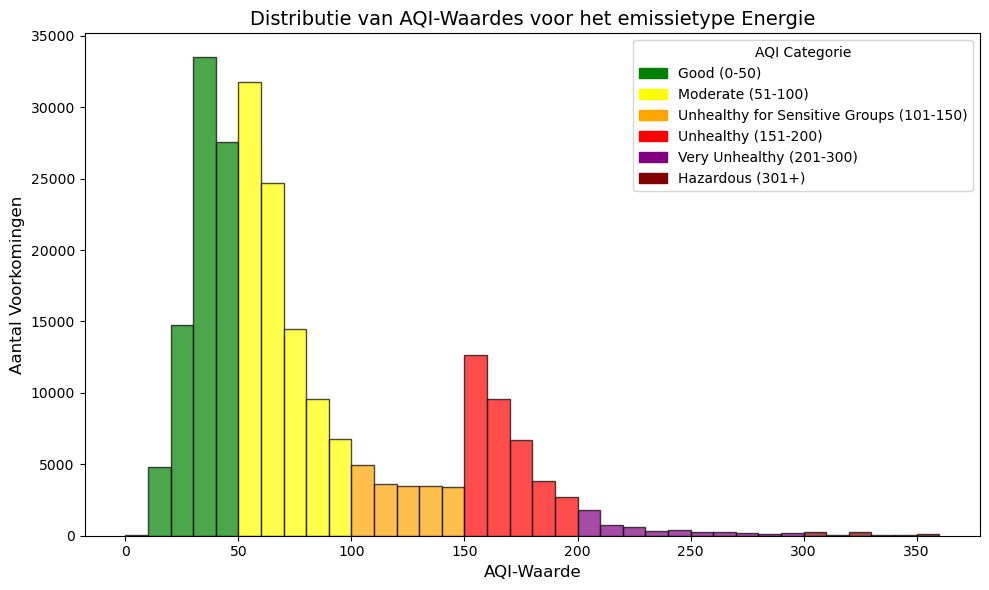

```python
exec(open('Energy_Verspreiding.py').read())
```

Uit bovenstaande grafiek is het volgende af te lezen:

- Het aantal voorkomingen in de Good en Moderate categorisatie is ongeveer hetzelfde, maar Moderate heeft net wat meer frequenties.
- Terwijl de frequentie voorkomingen steeds minder wordt, is er op eens een stijging wanneer deze aankomt bij de Unhealthy categorisatie.

Hieruit is te halen dat de opwekking van energie in deze mate de uitstoot slecht beïnvloed, maar dat het ook redelijk onder controle is wanneer de grootste distributie binnenin Good en Moderate zit.

Om ook een idee te krijgen van deze verspreiding waneer er wordt gekeken naar de verschillende emissieredenen, is er nog een grafiek hieronder weergegeven die deze weergeeft.

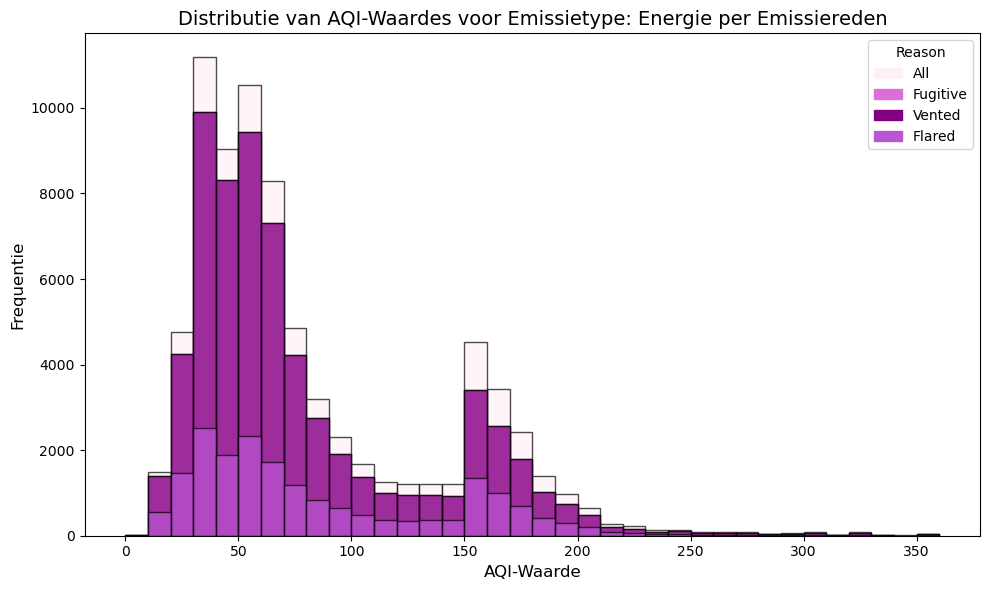

```python
exec(open('Energy_reason.py').read())
```

In de bovenstaande grafiek is de verdeling van de eerdere grafiek nogmaals weergegeven, maar zijn ditmaal de verspreiding van de emissieredenen per AQI-Waarde weergegeven.

Zoals in de legenda te zien is, zouden er vier verschillende redenen aanwezig moeten zijn, maar in de grafiek zijn er maar drie te zien in de vorm van;

- Flared
- Vented
- All

Dit betekend dat de Fugitive emissiereden óf heel klein is, óf precies dezelfde grootte heeft als een van de anderen emissie redenen. Wanneer we terugkijken naar Our World in Data grafiek is er echter te zien dat er dat er haast drie miljard uitstoot was ontstaan door de Fugitive emissiereden.

Om deze reden, en door het feit dat er al vaker een gedupliceerde waarde in deze dataset is voorgekomen, is het waarschijnlijker dat de Fugitive emissireden eenzelfde grootte heeft als een andere emissiereden;

```python
exec(open('Reason_Table.py').read())
```

```
      Reden  Aanwezigheid
0       All         77997
1  Fugitive         66466
2    Vented         66466
3    Flared         19730
```

Uit de kleine tabel is af te lezen dat er inderdaad een precies overlap is tussen de waardes van de Fugitive en Vented emissiereden, en dat hierom deze waarde niet visueel aanwezig was in de bovenstaande grafiek. Ook dit resultaat is waarschijnlijk foutief en gebaseerd op een foute dataset.

Wel interessant in de eerdere grafiek is het onderzoeken van de verdeling van emissieredenen, in de abrupte piek van de ongezonde AQI-Waarde. Voor de volgende observatie is het nodig om de "All" Emissiereden te veronachtzamen, in dat deze alle emissiredenen omvat, en dus niet veel toevoegd aan het onderscheiden van de invloed van de verschillende emissieredenen.

Uit de grafiek af te lezen dat de Flared emissiereden voor de Good en Moderate AQI-Categorisatie meestal maar 1/3 van de gehele staaf (zonder "All") opneemt, maar naarmate de grafiek afloopt naar de slechtere AQI-Categorisatie, is er te zien dat de Flared emissiereden steeds meer oppervlakte opneemt van de gehele staaf.

Wanneer we losstaand naar de All emissiereden kijken, kunnen we echter ook zien dat deze ook een groot deel van de staaf opneemt naarmate de AQI-Categorisatie slechter wordt;

Omdat er in de All staaf nog meer Flared emissieredenen zitten, het grote aandeel van de All staaf in de slechtere AQI-Categorisatie, en het feit dat de Flared emissiereden een groter aandeel heeft in de verdeling van ongezonde AQI-Waardes, is er een conclusie te trekken dat deze manier van uitstoot een veel slechtere invloed heeft op de AQI-Waarde dan de andere uitstoot manieren.

### Deelvraag 4

#### Invloed van emissietypes op emissiehoeveelheid

*Welke emissietypes hebben in het algemeen de grootste invloed op de emissiehoeveelheid?*

Uit de vorige deelvragen is er al ondervonden dat de huidge theorie is dat de Flared emissiereden mogelijk de negatieve invloed kan hebben op de AQI-Categorisatie. Daarnaast was er ook besloten om niet verder in te gaan op de verschillende emissietypes, maar juist op de emissieredenen van de grootste emissietype: Energie.

Om te illustreren waarom er verder wordt ingezoomd op Energie, is hieronder een grafiek weergegeven waarin de verdeling van emissietype op de totale emissieuitstoot is gevisualiseerd.

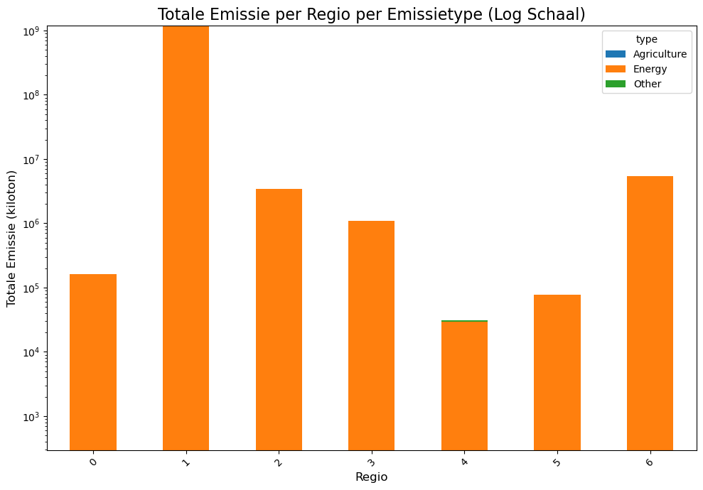

```python
exec(open('Type_Emission.py').read())
```

Zoals er te zien is valt er totaal niks uit dit resultaat te behalen voor het beantwoorden van de huidige deelvraag, behalve dat er het emissietype: Energie inderdaad de meeste invloed op de AQI-Categorisatie.

Om deze reden is het net zo makkelijk om door te zoeken naar emissiereden binnenin Energie, in dat energie toch 99% van de emissieuitstoot is volgens de foutieve dataset.

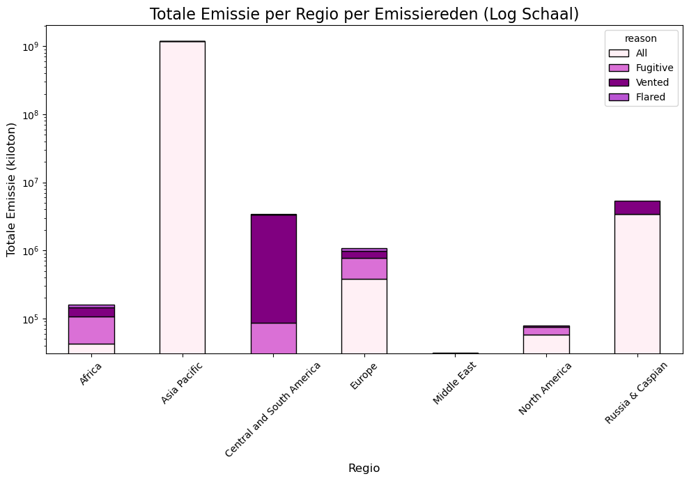

```python
exec(open('Emissie_Reden.py').read())
```

Een probleem dat tegen was gekomen tijdens deelvraag 3 is dat de "All" reden het onderzoek een beetje bederfd in dat het moeilijk is om een conclusie te trekken over emissieredenen, wanneer deze emissieredenen niet zijn opgesplitst.

Ook is de preciese verdeling van elke bar moeilijk in te schatten omdat de verdeling rommelig is door de logaritmische schaal, waarvoor er een overzichtelijke tabel hieronder wordt weergegeven.

In het geval van bovenstaande grafiek is al snel te zien dat vrijwel de gehele emissieuitstoot van Azië-Stille Oceaan is opgemaakt uit "alle redenen", en dat ook voor regio's zoals het Midden-Oosten, Noord-Amerika, en Rusland een groot aandeel "alle redenen" is.

Het is logisch dat er bij veel processen gebruik wordt gemaakt van de verschillende uitstootredenen, maar dat betekend ook dat er geen grondige conclusie kan worden getrokken over de invloed van redenen gebaseerd op deze data. En dat de enige conclusie die ik nu kan maken over de waarneembare redenen kan gaan.

```python
exec(open('Emissie_Reden_Table.py').read())
```

|  | Regio | All (%) | Fugitive (%) | Vented (%) | Flared (%) |
| --- | --- | --- | --- | --- | --- |
| 0 | Africa | 26.25 | 39.44 | 23.51 | 10.81 |
| 1 | Asia Pacific | 99.96 | 0.02 | 0.01 | 0.00 |
| 2 | Central and South America | 0.76 | 1.75 | 96.26 | 1.23 |
| 3 | Europe | 35.25 | 35.77 | 19.23 | 9.75 |
| 4 | Middle East | 77.92 | 15.73 | 4.90 | 1.45 |
| 5 | North America | 74.22 | 21.19 | 4.60 | NaN |
| 6 | Russia & Caspian | 64.26 | 0.02 | 35.72 | NaN |

In het geval van bovenstaande grafiek is al snel te zien dat vrijwel de gehele emissieuitstoot van Azië-Stille Oceaan is opgemaakt uit "alle redenen", waardoor een van de grote onderzoeksonderwerpen geen toevoeging hebben op de huidige deelvraag.

Één troost die uit deze grafiek kan worden gehaald is dat Centraal en Zuid Amerika, Europa, Afrika, en Rusland allemaal een hoog aandeel aan Vented emissieredenen hebben, en al deze regio's hebben een goede AQI-Categorisatie, behalve Afrika die een redelijke AQI-Categorisatie heeft.

Dit zou een indicatie kunnen zijn dat een Vented emissiereden een positieve invloed heeft op de AQI-Categorisatie.

Daarnaast hebben Afrika, Europa, en Noord-Amerika ook een groot aandeel in Fugitive emissieredenen, wat ook kan betekenen dat deze een redelijk positieve invloed heeft op AQI-Categorisatie.

Echter valt er niks te concluderen aan de hand van deze data, in dat de hypothese eerst was dat de Flared emissiereden juist de variabele was die AQI-Categorisatie negatief beïnvloedde, maar het Midden-Oosten heeft maar een klein aandeel in waarneembare Flared emissieredenen wat deze hypothese ontkracht.

Er is natuurlijk altijd de mogelijkheid dat een groot aandeel van "Alle redenen" aanzienlijk veranderd gebaseerd op regio, en dat het Midden-Oosten en Azië-Stille Oceaan heel veel Flared emissiredenen hebben, maar deze is op het moment niet waar te nemen.

Uit deze deelvraag zijn de volgende bevindingen waargenomen met betrekking tot de hypothese:

- Het Emissietype: Energie is vrijwel 99% van alle uitstoot volgens de dataset, en kan dus geen verficatie zijn voor positieve of negatieve invloed op AQI-Categorisatie.
- Door het bestaan van Emissiereden: All is er geen conclusie te maken over de negatieve invloed van Emissiereden: Flared op AQI-Categorisatie.
- Uit de visuele data is te verkrijgen dat Emissiereden: Vented een goede invloed heeft op AQI-Categorisatie.

## Explanatory Data Analysis

De hoofdvraag was als volgt beschreven:

*Hebben bepaalde emissies die zijn ontstaan door specifieke emissietypes een invloed op de gemiddelde waarde van de verschillende AQI-types in verhouding tot de grootte van de verschillende regio’s?*

Deze hoofdvraag is beantwoord met de conclusies die uit de deelvragen te halen zijn:

- Azië-Stille Oceaan en het Midden-Oosten hebben veruit de slechtste AQI-Categorisatie.
- Rusland en Centraal en Zuid-Amerika hebben de beste AQI-Categorisatie.
- De grootte van een regio heeft dus **geen** invloed op AQI-Categorisatie.
- Het Emissietype: Energie heeft in deze dataset veruit de grootste invloed op AQI-Categorisatie en uitstoot, maar kan niet gedefiniëerd worden als dé invloed, in dat de data duidelijk fout is.
- Binnenin de verschillende AQI-Waardes, kwam Emissiereden: Flared het meeste voor in de slechtere AQI-Categorisaties.
- Er valt op het moment geen conclusie te trekken over de invloed van emissieredenen op AQI-Categorisatie omdat Emissiereden All een te groot aandeel heeft in de som van uitstoot.

De originele hypothese was als volgt beschreven:

*Specifieke emissietypes hebben een hogere invloed op de gemiddelde waardes van de verschillende AQI-types, waarvan deze invloed wordt geamplificeerd door een hogere emissie uitstoot gebaseerd op de grootte van een regio.*

Het huidige antwoord op deze hypothese is dat het niet persé het emissietype is dat invloed heeft op de gemiddelde waardes van de verschillende AQI-types, maar dat het juist de emissiereden is die deze zo erg beïnvloed.

Ondanks het feit dat er geen grondige conclusie gemaakt kan worden met de huidige dataset door de aanwezigheid van Emissiereden: All, is er nog steeds de waarneming uit Deelvraag 3:

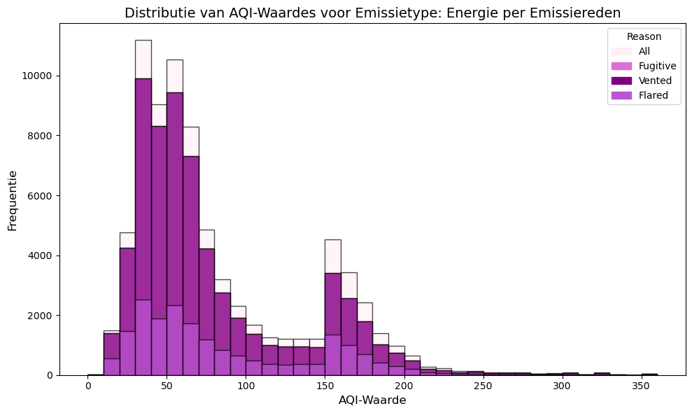

```python
exec(open('Energy_reason.py').read())
```

In bovenstaande grafiek was er bekeken wat de verdeling was van Emissieredenen per AQI-Waarde om zo waar te nemen was of er ergens een connectie tussen de twee variabelen lag. Tijdens deze deelvraag was er een korte observatie over de aanwezigheid van Emissiereden: Flared in de slechtere AQI-Waardes:

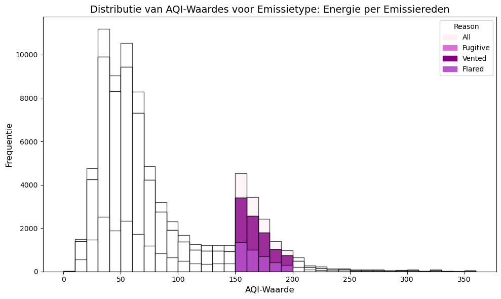

```python
exec(open('Emissie_Reden_White.py').read())
```

Ook is er een kleine assumptie dat binnenin Emissiereden: All er een groot aandeel Flared is, al wordt deze niet meegenomen in het verdere onderzoek.

Om te beginnen wordt hieronder de percentuele verdeling van de bovenstaande geïsoleerde grafiek weergegeven:

```python
exec(open('Emissie_Reden_Isolated.py').read())
```

|  | AQI Range | All (%) | Fugitive (%) | Vented (%) | Flared (%) |
| --- | --- | --- | --- | --- | --- |
| 0 | 150-159 | 35.7 | 26.8 | 26.8 | 10.6 |
| 1 | 160-169 | 35.9 | 26.8 | 26.8 | 10.5 |
| 2 | 170-179 | 36.2 | 26.7 | 26.7 | 10.4 |
| 3 | 180-189 | 36.1 | 26.7 | 26.7 | 10.5 |
| 4 | 190-199 | 35.8 | 26.8 | 26.8 | 10.5 |

Wanneer er naar de grafiek gekeken wordt leek het erop alsof een groot deel van de bar was onderverdeeld onder het Emissietype: Flared, echter is het mij nu snel duidelijk geworden dat dit maar een illusie is doordat Emissietype: Fugitive en Emissietype: Vented precies dezelfde waardes hebben, en dus identiek aan elkaar in de grafiek zijn gezet in plaats van op elkaar gestapeld.

Deze identieke data binnenin emissiereden lijkt ook weer een fout binnenin de dataset te zijn.

Ondanks het feit dat de observatie over de aanwezigheid van een groot deel Emissietype: Flared nu schijnbaar overdreven lijkt, is er toch nog de mate van het feit dat het lijkt alsof het aandeel toch groter wordt naarmate de AQI-Categorisatie verslechterd.

Het is duidelijk dat de AQI-Categorisatie per waardes van 10 grotendeels hetzelfde lijken, wat betekend dat in de volgende stap alle AQI-Waardes worden bekeken in stappen van 50:

```python
exec(open('Emissie_Reden_ALL.py').read())
```

|  | AQI Bin | All (%) | Flared (%) | Vented (%) | Fugitive (%) |
| --- | --- | --- | --- | --- | --- |
| 0 | 0-50 | 32.8 | 8.0 | 29.6 | 29.6 |
| 1 | 50-100 | 33.5 | 7.7 | 29.4 | 29.4 |
| 2 | 100-150 | 34.7 | 10.2 | 27.5 | 27.5 |
| 3 | 150-200 | 35.9 | 10.5 | 26.8 | 26.8 |
| 4 | 200-300 | 35.6 | 10.6 | 26.9 | 26.9 |
| 5 | 300+ | 36.9 | 10.5 | 26.3 | 26.3 |

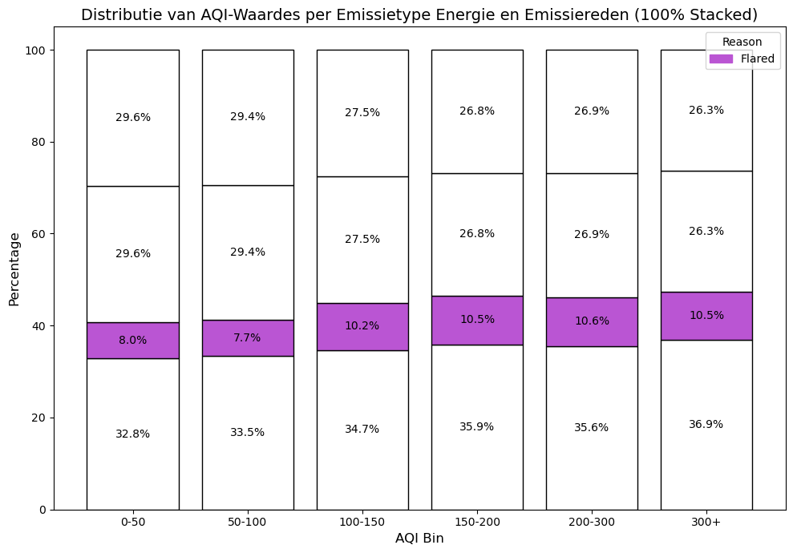

```python
exec(open('Flared_Bins.py').read())
```

Uit bovenstaande visuelen is te achterhalen dat er inderdaad een grote stijging in het percentuele aandeel van Emissiereden: Flared is naarmate de ongezonde AQI-Categorisatie bevonden wordt.

Daarnaast is ook op te merken dat de percentuele verdeling van Emissiereden: All ook stijgt, terwijl de andere emissieredenen dalen. Er kan een hypothese opgestelt kunnen worden in hoe de Emissiereden: Flared binnenin Emissiereden: All meer wordt wanneer slechte AQI-Categorisatie naar voren komt. Gezien er al laten zien is dat Emissiereden: Vented en Emissiereden: Fugitive positieve invloeden hebben op AQI-Categorisatie.

Uiteindelijk is deze observatie gebaseerd op de algemene AQI-Waarde, maar zoals in Deelvraag 1 was te zien, liggen de enige hoge AQI-Waardes binnenin de Ozone en PM2.5 AQI-Types. Om deze reden is het belangrijk voor verder onderzoek om deze waardes tegen elkaar op te zetten, en om de verdeling van emissieredenen ook binnenin deze AQI-Types te onderzoeken.

In het geval van de Ozone AQI-Categorisatie is alleen de volgende data van belang:

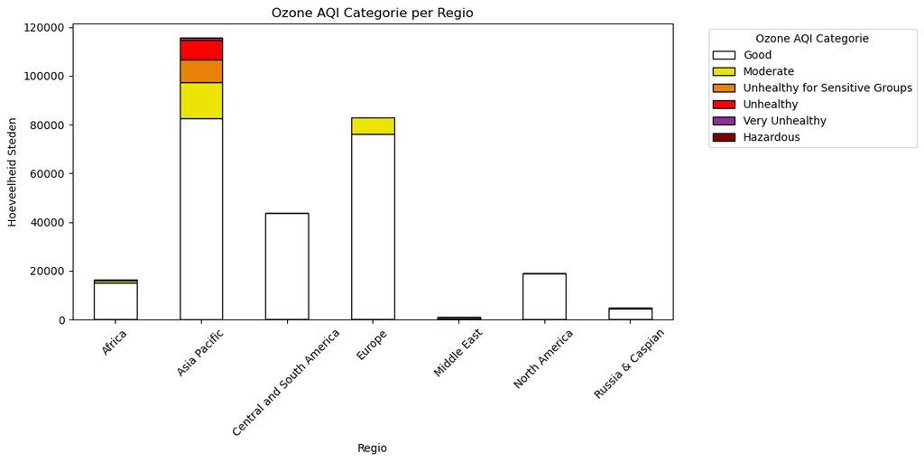

```python
exec(open('Ozone_White.py').read())
```

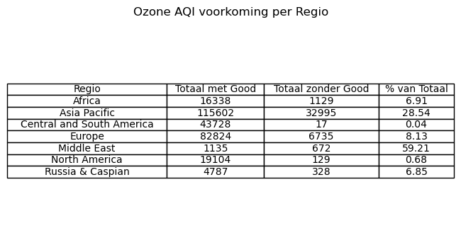

```python
exec(open('Ozone_White_Table.py').read())
```

Uit de bovenstaande grafiek en tabel is waar te nemen dat de meest relevante data voor het verdere onderzoek te halen valt uit Azië-Stille Oceaan en het Midden-Oosten. De andere regio's hebben namelijk een te klein aandeel in niet goede AQI-Categorisatie, dat er niet genoeg data verkrijgbaar is om conclusies uit te trekken.

Voor de PM2.5 AQI-Waardes is de volgende data relevant:

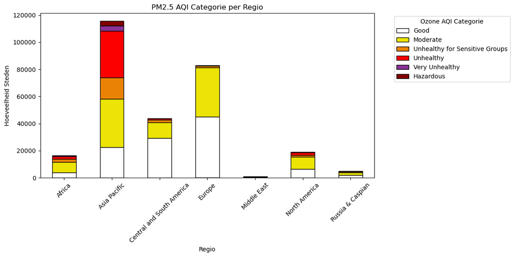

```python
exec(open('PM2.5_White.py').read())
```

[figure not shown]

```python
exec(open('PM2.5_White_Table.py').read())
```

De AQI-Waardes binnenin het AQI-Type: PM2.5 zijn wel goed te gebruiken, in dat de aandelen van niet goede AQI-Categorisatie een groot deel opmaken van het geheel. Dit betekend ook dat deze een verdere mogelijkheid aanbieden om te ontleden en evalueren, zodat daaruit verdere conclusies getrokken kunnen worden over de invloed van emissieredenen op AQI-Waardes.

Uiteindelijk was het echter de bedoeling dat deze twee waardes tegen elkaar werden opgezet om te zien of er enige relatie is die de slechte AQI-Waarde beïnvloed.

De eerste grafiek zet deze twee waardes van alle regio's tegen elkaar op:

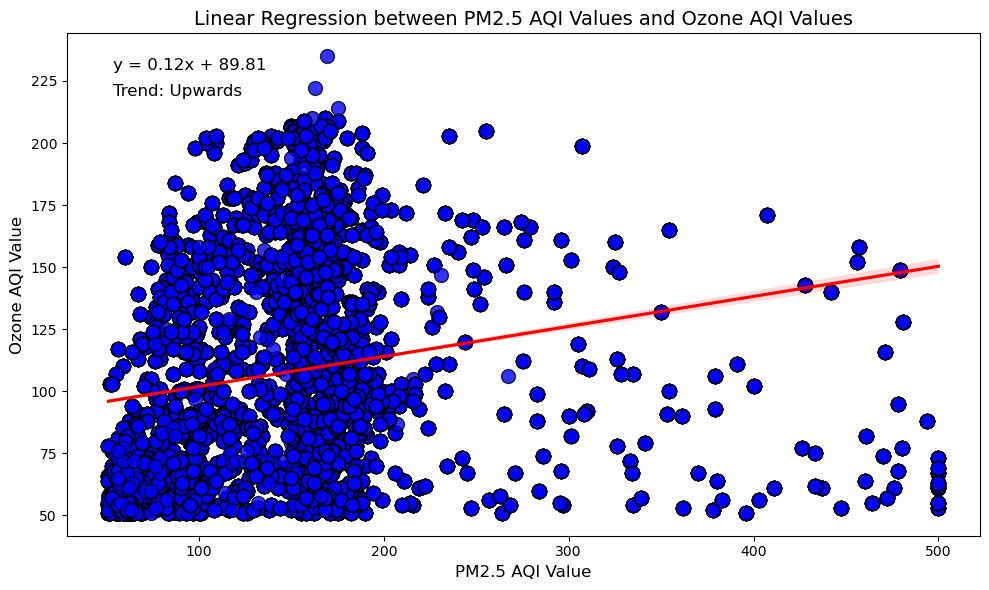

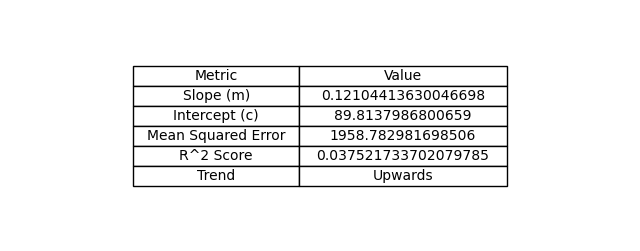

```python
exec(open('Linear_Regression.py').read())
```

Uit de bovenstaande grafiek en tabel zijn de volgende waarnemingen te halen:

- Zoals uit de eerdere grafiek te halen was, zit er een grote concentratie van de AQI-Waardes binnenin een AQI-Categorisatie van 100 - 200.
- De algemene trendlijn gaat omhoog, wat betekend dat, in het algemeen, wanneer de Ozone AQI-Waarde omhoog gaat, de PM2.5 AQI-Waarde ook omhoog gaat.
- Deze verhoging is echter erg smal, in dat de hellingsgraad vrij klein is ondanks het positieve getal.
- De zone die de lijn herbergd wordt steeds breder naarmate de waardes hoger worden, wat suggereert dat de relatie tussen de twee waardes steeds zwakker wordt naarmate deze hoger wordt.
- Daarnaast is er duidelijk uit de tabel te halen dat de relatie tussen de twee vergeleken waardes eigenlijk gewoon niet bestaat, in dat de MSE ontzettend hoog is en dus suggereert dat het model dat deze waardes berekent niet goed past bij de actuele waardes binnenin de dataset.
- Ook de R^2 Score suggereert dat maar 3.75% van de Ozone AQI-Waardes worden uitgelegd doormiddel van dit model, wat betekend dat er óf geen relatie is tussen de twee waardes, óf dat deze relatie gewoonweg erg zwak is.

Om te onderzoeken of deze trend zich ook doorzet wanneer we alleen de waardes van de regio's met de slechtste AQI-Categorisatie (Azië-Stille Oceaan en het Midden-Oosten) tegen elkaar opzetten, is dezelfde grafiek nogmaals gecreëerd met alleen waardes die toebehoren aan deze regio's:

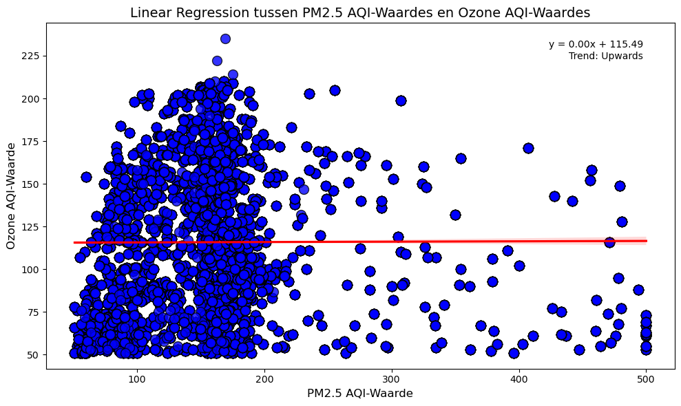

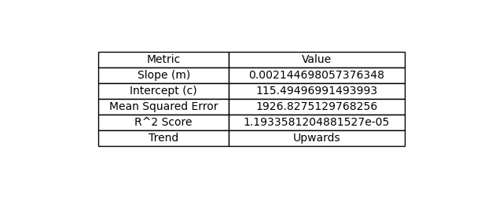

```python
exec(open('Linear_Regression_Region.py').read())
```

Deze observatie valt verder te bewijzen wanneer de waardes van de andere regio's tegen elkaar worden opgezet, in dat de concentratie van beiden waardes voor de lagere AQI-Waardes er voor zorgt dat er zoiezo een stijgende trendlijn ontstaat wanneer er enkele uitzonderingen zijn. Deze uitzonderingen zijn er ook wel degelijk in dat er in de eerdere deelvragen al bewezen is dat er foutieve uitliggers in de dataset zitten:

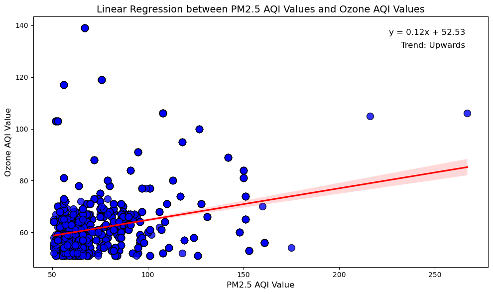

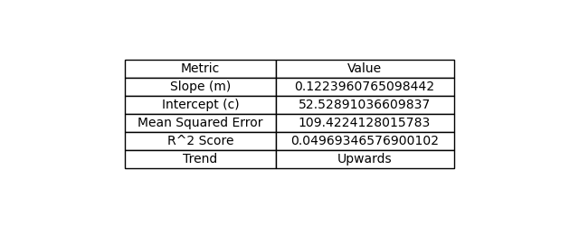

```python
exec(open('Linear_Regression_GOOD.py').read())
```

Uit deze grafiek en tabel zijn de volgende waarneming te halen:

- De sloop is weer positief, al is deze weer klein, daarnaast is deze vrijwel hetzelfde als de sloop uit de eerste lineaire regressie, wat insinueert dat deze sloop dus altijd eenzelfde vorm gaat hebben die vrijwel geen relatie aantoont.
- De MSE daarentegen is veel lager dan bij de andere grafieken, wat suggereert dat het dus aan de variabelen van Azië-Stille Oceaan en het Midden-Oosten lag dat deze error aangaf.
- Echter suggereert dit ook dat de enige reden dat er weinig errors zijn, is omdat de grote uitligger (Azië) niet aanwezig is, wat verder impliceert dat het model inderdaad niet geschikt is voor het evalueren van deze waardes.

Om deze waarnemingen nog beter te laten zien, worden de twee grafieken met elkaar gecombineerd in de vorm van meerdere trendlijnen:

```
No artists with labels found to put in legend.  Note that artists whose label start with an underscore are ignored when legend() is called with no argument.
```

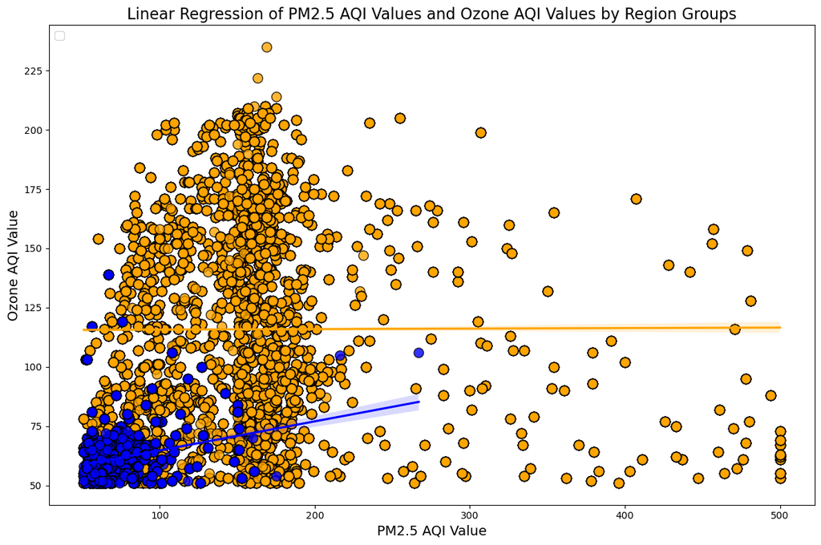

```python
exec(open('Multiple_Regression.py').read())
```

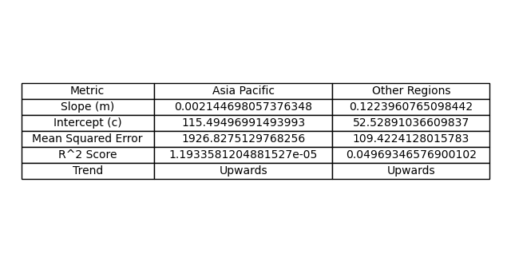

```python
exec(open('Multiple_Table.py').read())
```

De bovenstaande grafiek laat het volgende zien:

- Er is veel minder data aanwezig voor de andere regio's wanneer deze worden vergeleken met Azië-Stille Oceaan.
- Er zijn twee hoge uitliggers voor de andere regio's die, door de weinige data, ervoor zorgen dat de trendlijn een bepaalde richting op gaat.
- Dit is beter te zien wanneer je de data van Azië ziet, en de realisatie opdoet dat deze vrijwel geen uitliggers hebben die alleen de trend bepalen.

De waarnemingen van de bovenstaande grafieken en tabellen leiden tot de volgende conclusie:

Deze dataset zal altijd een positieve trend laten zien wanneer alle data wordt vergeleken door de vele uitliggers en de concentratie binnenin de lagere waardes.

Maar wanneer er dus wordt gekeken naar regio's die zoiezo al slechte AQI-Categorisatie hebben, wordt het al snel duidelijk dat de enige relatie tussen Ozone en 2.5 AQI-Waardes gewoonweg afhangt van de algemene Luchtkwaliteit van de regio.

## Conclusie

Het is belangrijk om nogmaals duidelijk te maken dat de gebruikte dataset ontzettend veel foutieve data bevat in de vorm van:

- Onjuiste AQI-Waardes
- Identieke data voor Emissietypes en Emissieredenen.
- Één Emissietype dat 99% van de uitstoot veroorzaakt volgens de dataset.

Daarnaast leent de dataset zich niet aan dieper onderzoek door de dominante aanwezigheid van Emissiereden: All, wat te veel interpretatie aan de gebruiker over laat.

Om deze redenen is dit rapport eerder een onderzoek geworden dat meer de onderliggende structuur van het gehele proces probeert weer te geven, in plaats van een onderzoek naar preciese cijfers dat een grondige conclusies kan opleveren.

In dit rapport is er vooral nadruk gelegd op, als het ware, een kruisverhoor, waarin de data van deze dataset wordt vergeleken met andere openbare data om deze zo te kunnen verifiëren.

Ondanks het feit dat de data foutief is, zijn er toch meerdere interessante observaties gemaakt in de zin van het beantwoorden van de deelvragen, waarna ook een interessante bevinding is voortgekomen in de zin van de invloed van Emissiereden: Flared.

Dit rapport en haar toegevoegde bewerkingen zouden in principe een goede fundering kunnen zijn voor eenzelfde onderzoek wanneer deze wordt ondervonden met gebruik van correcte data omliggende dit onderwerp. De data is incorrect maar geeft nog steeds een indicatie of trend aan van de data binnenin luchtkwaliteit, wat betekend dat de waarnemingen binnenin dit rapport niet uit het niets zijn ontstaan, en dat de desbetreffende handelingen die er toe doen om deze waarnemingen te transformeren ook waarborging leveren wanneer er interesse is om dit onderzoek opnieuw uit te voeren.

Om dit rapport te concluderen wordt de volgende hypothese beantwoord en verantwoord:

*Specifieke emissietypes hebben een hogere invloed op de gemiddelde waardes van de verschillende AQI-types, waarvan deze invloed wordt geamplificeerd door een hogere emissie uitstoot gebaseerd op de grootte van een regio.*

Zoals al eerder is waargenomen hebben de volgende factoren totaal geen invloed op de AQI-Categorisatie:

*Grootte van regio's*

De hypothese was dat de grootte van regio's zorgde voor meer uitstoot, en dat deze verhoogde uitstoot een negatieve invloed had op de AQI-Waardes. Een grotere regio zorgt **niet** voor meer uitstoot, in dat, naast Azië-Stille Oceaan, de kleinere regio's juist de meeste uitstoot hadden.

Daarnaast heeft de grootte van de regio ook **niet** een directe negatieve invloed op AQI-Categorisatie in dat de grootste regio **én** de kleinste regio beiden de slechtste AQI-Categorisatie hebben, terwijl de regio's die daar tussen zitten juist een goede AQI-Categorisatie hebben.

*Specifieke emissietypes*

In het geval van de huidige dataset is emissietype geen negatieve *óf* positieve invloed op AQI-Categorisatie, in dat het Emissietype: Energie een te groot percentueel aandeel heeft in het voorkomen van emissietypes om enige conclusie te trekken of om verder onderzoek te doen rondom emissietypes.

*Invloed op verschillende AQI-types*

Daarnaast is er in het onderzoek naar lineaire regressie naar voren gekomen dat er vrijwel geen relatie is tussen twee AQI-Waardes, en dat deze geïsoleerd hoog of laag zijn aan de hand van de algemene luchtkwaliteit binnenin een regio. Als een regio een hoge algemene AQI-Waarde heeft, dan zijn alle verschillende AQI-Waardes hoog, maar dat ligt niet in verband met elkaar, maar gewoonweg aan de andere factoren.

*verantwoording*

Zoals waar te nemen is, zijn alle facotren die aan het begin van het document zijn opgesteld om de hypothese te bewijzen ontkracht, wat betekend dat de hypothese geheel incorrect was.

Echter is er tijdens het onderzoek wel een kleine ontdekking voortgekomen die mogelijk wel enige invloed heeft op AQI-Categorisatie.

*Invloed van emissiereden*

Dit kan geïnterpreteerd worden als een inzicht dat de Emissiereden: Flared binnenin Emissiereden: All stijgt wanneer negatieve AQI-Categorisatie vaker voorkomt.

Al in al betekend het bovenstaande dat het inzicht dat is verkregen via dit rapport en de dataset inhoud dat Emissiereden: Flared een negatieve invloed heeft op AQI-Categorisatie, en dat Emissiereden: Fugitive en Emissiereden: Vented een positievere invloed hebben op AQI-Categorisatie.

Samenvattend is de enige waarneembare factor die invloed heeft op AQI-waardes en dus AQI-Categorisatie; **Emissiereden**.

## Toekomst

Zoals in de conclusie is beschreven is dit onderzoek eerder een beschrijving en fundering geworden voor een verder onderzoek met een correcte dataset.

Uiteindelijk is het niet persé foutieve AQI-Waardes die dit rapport zo erg negatief aantasten, in de zin dat er nooit ontzettend veel uitliggers aanwezig zijn, maar dat het eerder ligt aan identieke waardes binnenin emissietypes, en emissieredenen, en de foutieve representatie van deze kolommen.

Het aandeel dat Emissietype: Energie heeft in deze dataset, oftewel 99%, zorgt ervoor dat er niet meer onderzoek kan worden gepleegd naar andere emissietypes, en de respectieve deelsectoren en emissieredenen van deze emissietypes.

Deelsectoren zijn verder ook niet besproken in dit rapport, omdat de identieke data zich daar niet aan zou lenen, het zou gewoon een weergave zijn van vijf verschillende deelsectoren van hetzelfde aantal die ieder precies dezelfde emissiereden verdeling hebben, wat dus totaal geen nieuwe inzichten zou creëren.

Een toekomstig onderzoek zou dus verder in kunnen gaan op de ondervonden observaties, en kan tegelijkertijd ook de deelsectoren betrekken in dit onderzoek, zodat er een compleet beeld kan worden gecreëerd over de invloed van uitstoot factoren op de luchtkwaliteit en AQI-Waardes en AQI-Categorieën.